# Regression Models

Xing Su (modified)

# 1 Introduction to Regression

- **Intro**: Regression models are the workhorse of data science. They are the most well described, practical and theoretically understood models in statistics. A data scientist well versed in regression models will be able to solve an incredible array of problems.  
  Perhaps the key insight for regression models is that they produce highly interpretable model fits. This is unlike machine learning algorithms, which often sacrifice interpretability for improved prediction performance or automation. These are, of course, valuable attributes in their own rights. However, the benefit of simplicity, parsimony and intrepretability offered by regression models (and their close generalizations) should make them a first tool of choice for any practical problem.
- linear regression/linear models $\rightarrow$ go to procedure to analyze data
- *Francis Galton* invented the term and concepts of regression and correlation
  - he predicted child’s height from parents height
- questions that regression can help answer
  - prediction of one thing from another
  - find simple, interpretable, meaningful model to predict the data
  - quantify and investigate variations that are unexplained or unrelated to the predictor $\rightarrow$ **residual variation**
  - quantify the effects of other factors may have on the outcome
  - assumptions to generalize findings beyond data we have $\rightarrow$ **statistical inference**
  - **regression to the mean** (see below)

# 2 Notation

- regular letters (i.e. $X$, $Y$) = generally used to denote **observed** variables
- Greek letters (i.e. $\mu$, $\sigma$) = generally used to denote **unknown** variables that we are trying to estimate
- $X_1, X_2, \ldots, X_n$ describes $n$ data points
- $\bar X$, $\bar Y$ = observed means for random variables $X$ and $Y$
- $\hat \beta_0$, $\hat \beta_1$ = estimators for true values of $\beta_0$ and $\beta_1$

## 2.1 Empirical/Sample Mean

- **empirical mean** is defined as
  $$\bar X = \frac{1}{n}\sum_{i=1}^n X_i$$
- **centering** the random variable is defined as
  $$\tilde X_i = X_i - \bar X$$
  - mean of $\tilde X_i$ = 0

## 2.2 Empirical/Sample Standard Deviation & Variance

- **empirical variance** is defined as
  $$S^2 = \frac{1}{n-1} \sum_{i=1}^n (X_i - \bar X)^2
  = \frac{1}{n-1} \left( \sum_{i=1}^n X_i^2 - n \bar X ^ 2 \right)
  \Leftarrow \mbox{shortcut for calculation}$$
- **empirical standard deviation** is defined as $S = \sqrt{S^2}$
  - average squared distances between the observations and the mean
  - has same units as the data
- **scaling** the random variables is defined as $X_i / S$
  - standard deviation of $X_i / S$ = 1

## 2.3 Normalization

- **normalizing** the data/random variable is defined as
  $$Z_i = \frac{X_i - \bar X}{s}$$
  - empirical mean = 0, empirical standard deviation = 1
  - distribution centered at 0 and normalized data have units equal to # of standard deviations away from the original mean
    - *example*: $Z_1 = 2$ means that the data point is 2 standard deviations larger than the original mean
- normalization makes non-comparable data **comparable**

## 2.4 Empirical Covariance & Correlation

- Let $(X_i, Y_i)$ = pairs of data
- **empirical covariance** is defined as
  $$Cov(X, Y) = \frac{1}{n-1}\sum_{i=1}^n (X_i - \bar X) (Y_i - \bar Y) = \frac{1}{n-1}\left( \sum_{i=1}^n X_i Y_i - n \bar X \bar Y\right)$$
  - has units of $X \times$ units of $Y$
- **correlation** is defined as
  $$Cor(X, Y) = \frac{Cov(X, Y)}{S_x S_y}$$
  where $S_x$ and $S_y$ are the estimates of standard deviations for the $X$ observations and $Y$ observations, respectively
  - the value is effectively the covariance standardized into a unit-less quantity
  - $Cor(X, Y) = Cor(Y, X)$
  - $-1 \leq Cor(X, Y) \leq 1$
  - $Cor(X,Y) = 1$ and $Cor(X, Y) = -1$ only when the $X$ or $Y$ observations fall perfectly on a positive or negative sloped line, respectively
  - $Cor(X, Y)$ measures the strength of the linear relationship between the $X$ and $Y$ data, with stronger relationships as $Cor(X,Y)$ heads towards -1 or 1
  - $Cor(X, Y) = 0$ implies no linear relationship

# 3 Galton’s Data and Least Squares

- collected data from 1885 in `UsingR` package
- predicting children’s heights from parents’ height
- observations from the marginal/individual parent/children distributions

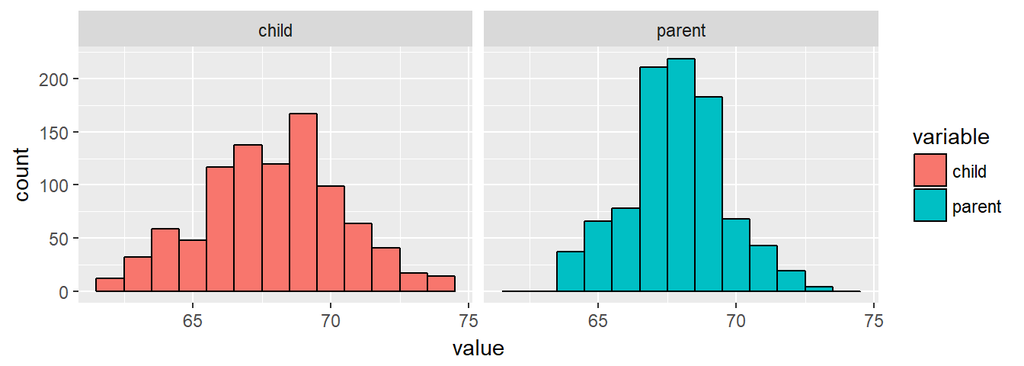

```r
# load necessary packages/install if needed
library(UsingR); data(galton)
library(ggplot2)
library(reshape)

long <- melt(galton)
g <- ggplot(long, aes(x = value, fill = variable))
g + geom_histogram(colour = "black", binwidth = 1) + facet_grid(. ~ variable)
```

- Consider only the children’s heights.
  - How could one describe the “middle”?
  - One definition: let $Y_i$ be the height of child $i$ for $i = 1, \ldots, n = 928$, then define the “middle” as the value of $\mu$ that minimizes
    $$\sum_{i=1}^n (Y_i - \mu)^2$$
  - This is physical center of mass of the histrogram.
  - You might have guessed that the answer is $\mu = \bar Y$.
    - Minimizing this sum $\rightarrow$ **least squares = empirical mean**
    - “middle” of children’s dataset $\rightarrow$ best predictor
  - **Note**: Use `manipulate` function to see what value of $\mu$ minimizes the sum of the squared deviations

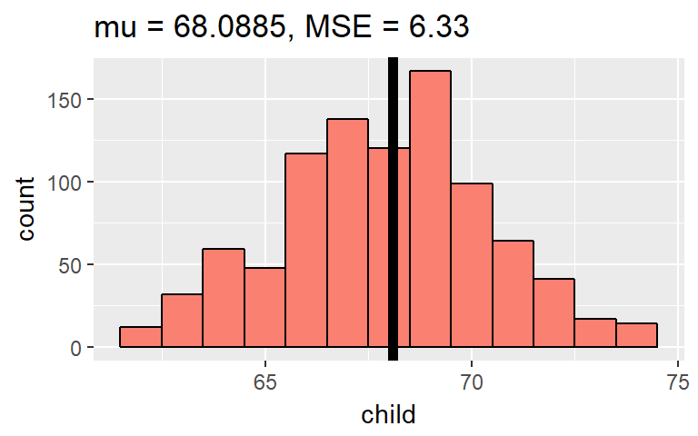

```r
# function to plot the histograms
myHist <- function(mu){
    # calculate the mean squares
    mse <- mean((galton$child - mu)^2)
    # plot histogram
    g <- ggplot(galton, aes(x = child)) + geom_histogram(fill = "salmon",
        colour = "black", binwidth=1)
    # add vertical line marking the center value mu
    g <- g + geom_vline(xintercept = mu, size = 2)
    g <- g + ggtitle(paste("mu = ", mu, ", MSE = ", round(mse, 2), sep = ""))
    g
}
# manipulate allows the user to change the variable mu to see how the mean squares changes
# library(manipulate)
# manipulate(myHist(mu), mu = slider(62, 74, step = 0.5))]

# mu that minimizes the sum is the empirical mean
myHist(round(mean(galton$child), 4))
```

- in order to visualize the parent-child height relationship, a scatter plot can be used
- **Note**: because there are multiple data points for the same parent/child combination, a third dimension (size of point) should be used when constructing the scatter plot; represents number of points at that $(X, Y)$ combination

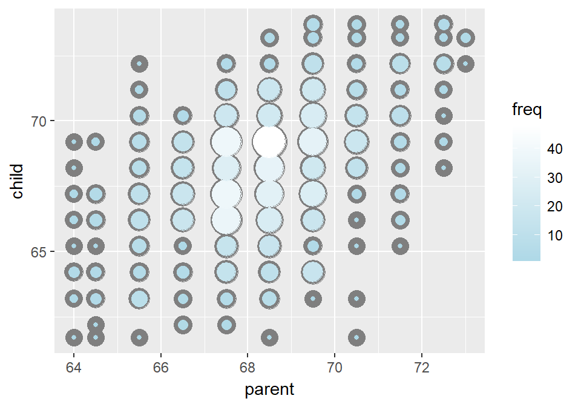

```r
library(dplyr)
# constructs table for different combination of parent-child height
freqData <- as.data.frame(table(galton$child, galton$parent))
names(freqData) <- c("child (in)", "parent (in)", "freq")
# convert to numeric values
freqData$child <- as.numeric(as.character(freqData$child))
freqData$parent <- as.numeric(as.character(freqData$parent))
# filter to only meaningful combinations
g <- ggplot(filter(freqData, freq > 0), aes(x = parent, y = child))
g <- g + scale_size(range = c(1, 10), guide = "none" )
# plot grey circles slightly larger than data as base (achieve an outline effect)
g <- g + geom_point(colour="grey50", aes(size = freq+10))
# plot the accurate data points
g <- g + geom_point(aes(colour=freq, size = freq))
# change the color gradient from default to lightblue -> $white
g <- g + scale_colour_gradient(low = "lightblue", high="white")
g
```

## 3.1 Derivation for Least Squares = Empirical Mean (Finding the Minimum)

- Let $X_i =$ **regressor**/**predictor**, and $Y_i =$ **outcome**/**result** so we want to minimize the squares:
  $$\sum_{i=1}^n (Y_i - \mu)^2$$
- Proof is as follows
  $$\begin{aligned}
  \sum_{i=1}^n (Y_i - \mu)^2 & = \sum_{i=1}^n (Y_i - \bar Y + \bar Y - \mu)^2 \Leftarrow \mbox{added} \pm \bar Y \mbox{which is adding 0 to the original equation}\\
  (expanding~the~terms)& = \sum_{i=1}^n (Y_i - \bar Y)^2 + 2 \sum_{i=1}^n (Y_i - \bar Y) (\bar Y - \mu) + \sum_{i=1}^n (\bar Y - \mu)^2 \Leftarrow (Y_i - \bar Y), (\bar Y - \mu) \mbox{ are the terms}\\
  (simplifying) & = \sum_{i=1}^n (Y_i - \bar Y)^2 + 2 (\bar Y - \mu) \sum_{i=1}^n (Y_i - \bar Y) +\sum_{i=1}^n (\bar Y - \mu)^2 \Leftarrow (\bar Y - \mu) \mbox{ does not depend on } i \\
  (simplifying) & = \sum_{i=1}^n (Y_i - \bar Y)^2 + 2 (\bar Y - \mu) (\sum_{i=1}^n Y_i - n \bar Y) +\sum_{i=1}^n (\bar Y - \mu)^2 \Leftarrow \sum_{i=1}^n \bar Y \mbox{ is equivalent to }n \bar Y\\
  (simplifying) & = \sum_{i=1}^n (Y_i - \bar Y)^2 + \sum_{i=1}^n (\bar Y - \mu)^2 \Leftarrow \sum_{i=1}^n Y_i - n \bar Y = 0 \mbox{ since } \sum_{i=1}^n Y_i = n \bar Y \\
  \sum_{i=1}^n (Y_i - \mu)^2 & \geq \sum_{i=1}^n (Y_i - \bar Y)^2 \Leftarrow \sum_{i=1}^n (\bar Y - \mu)^2 \mbox{ is always} \geq 0 \mbox{ so we can take it out to form the inequality}
  \end{aligned}$$
  - because of the inequality above, to minimize the sum of the squares $\sum_{i=1}^n (Y_i - \mu)^2$, **$\bar Y$ must be equal to $\mu$**
- An alternative approach to finding the minimum is taking the *derivative* with respect to $\mu$
  $$\begin{aligned}
  \frac{d(\sum_{i=1}^n (Y_i - \mu)^2)}{d\mu} & = 0 \Leftarrow \mbox{setting this equal to 0 to find minimum}\\
  -2\sum_{i=1}^n (Y_i - \mu) & = 0 \Leftarrow \mbox{divide by -2 on both sides and move } \mu \mbox{ term over to the right}\\
  \sum_{i=1}^n Y_i & = \sum_{i=1}^n \mu \Leftarrow \mbox{for the two sums to be equal, the sums must be equal or}\\
  \mu & = \frac{\sum_{i-1}^n Y_i}{n} = \bar Y\\
  \end{aligned}$$

# 4 Regression through the Origin

- Let $X_i =$ parents’ heights (**regressor**) and $Y_i =$ children’s heights (**outcome**)
- find a line with slope $\beta$ that passes through the origin at (0,0)
  $$Y_i = X_i \beta$$
  such that it minimizes
  $$\sum_{i=1}^n (Y_i - X_i \beta)^2$$
- **Note**: it is generally a bad practice forcing the line through (0, 0)

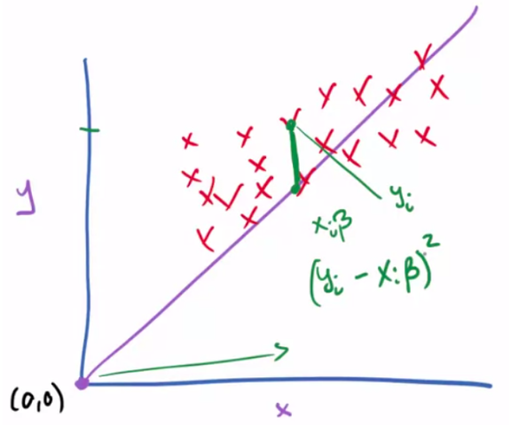

- *Centering Data/Gaussian Elimination*
  - subtracting the means from the $X_i$s and $Y_i$s moves the origin (reorienting the axes) to the center of the data set so that a regression line can be constructed
  - **Note**: this is **different** from regression through the origin, because it is effectively moving the regression line
  - **Note**: the line constructed here has an **equivalent slope** as the result from linear regression **with intercept**

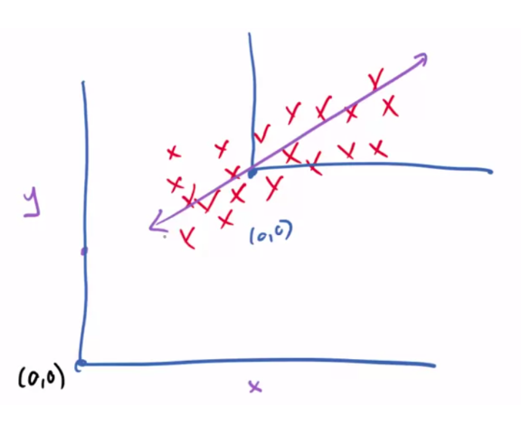

- Parents/Child Example: Finding the slope $\beta$

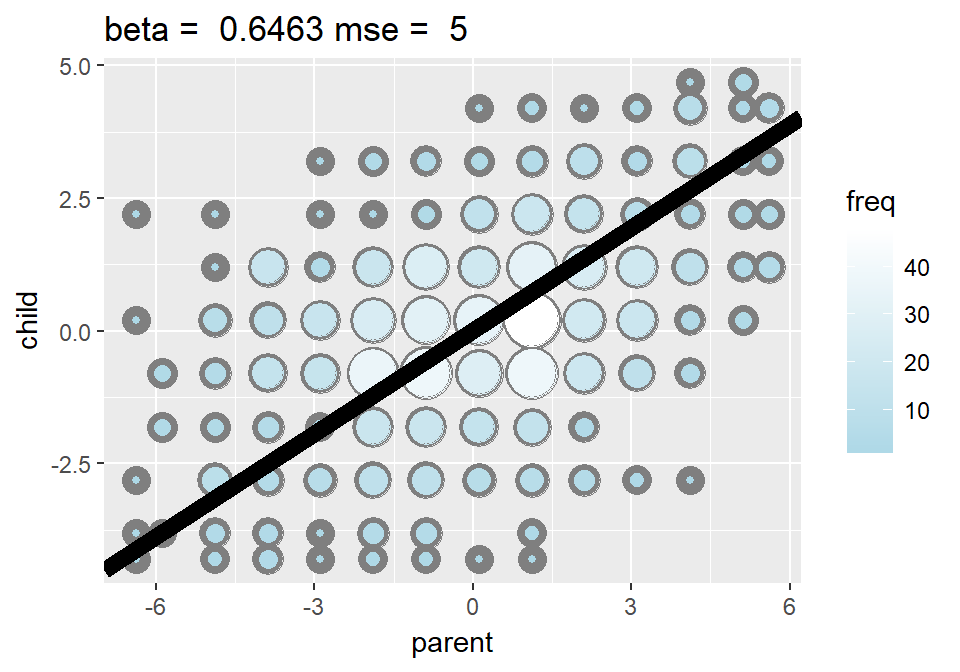

```r
# centering data
y <- galton$child - mean(galton$child)
x <- galton$parent - mean(galton$parent)
freqData <- as.data.frame(table(x, y))
names(freqData) <- c("child", "parent", "freq")
freqData$child <- as.numeric(as.character(freqData$child))
freqData$parent <- as.numeric(as.character(freqData$parent))
myPlot <- function(beta){
    g <- ggplot(filter(freqData, freq > 0), aes(x = parent, y = child))
    g <- g  + scale_size(range = c(1, 10), guide = "none" )
    g <- g + geom_point(colour="grey50", aes(size = freq+10))
    g <- g + geom_point(aes(colour=freq, size = freq))
    g <- g + scale_colour_gradient(low = "lightblue", high="white")
    g <- g + geom_abline(intercept = 0, slope = beta, size = 3)
    mse <- mean( (y - beta * x) ^2 )
    g <- g + ggtitle(paste("beta = ", beta, "mse = ", round(mse, 3)))
    g
}

# manipulate allows the user to change the slope to see how the mean squares changes
# manipulate(myPlot(beta), beta = slider(0.6, 1.2, step = 0.02))

# slope that minimizes the sum is calculated as follows
beta <- coef(lm(I(child - mean(child)) ~ I(parent - mean(parent)) - 1, data = galton))[1]
myPlot(round(beta, 4))
```

## 4.1 Derivation for $\beta$

- Let $Y = \beta X$, and $\hat \beta$ = estimate of $\beta$, the slope of the least square regression line
  $$\begin{aligned}
  \sum_{i=1}^n (Y_i - X_i \beta)^2 & = \sum_{i=1}^n \left[ (Y_i - X_i \hat \beta) + (X_i \hat \beta - X_i \beta) \right]^2 \Leftarrow \mbox{added } \pm X_i \hat \beta \mbox{ is effectively adding zero}\\
  (expanding~the~terms)& = \sum_{i=1}^n (Y_i - X_i \hat \beta)^2 + 2 \sum_{i=1}^n (Y_i - X_i \hat \beta)(X_i \hat \beta - X_i \beta) + \sum_{i=1}^n (X_i \hat \beta - X_i \beta)^2 \\
  \sum_{i=1}^n (Y_i - X_i \beta)^2 & \geq \sum_{i=1}^n (Y_i - X_i \hat \beta)^2 + 2 \sum_{i=1}^n (Y_i - X_i \hat \beta)(X_i \hat \beta - X_i \beta) \Leftarrow \sum_{i=1}^n (X_i \hat \beta - X_i \beta)^2 \mbox{ is always positive}\\
  & (ignoring~the~second~term~for~now,~for~\hat \beta ~to~be~the~minimizer~of~the~squares, \\
  & the~following~must~be~true)\\
  \sum_{i=1}^n (Y_i - X_i \beta)^2 & \geq \sum_{i=1}^n (Y_i - X_i \hat \beta)^2 \Leftarrow \hat \beta \mbox{ would have to be the minimizer, because every other } \beta \mbox{ value }\\
  & \mbox{creates a least square criteria that is at least as large or larger}\\
  & \Rightarrow 2 \sum_{i=1}^n (Y_i - X_i \hat \beta)(X_i \hat \beta - X_i \beta) = 0 \Leftarrow \mbox{if we can make this term zero, then we've found our estimate}\\
  (simplifying)& \Rightarrow \sum_{i=1}^n (Y_i - X_i \hat \beta) X_i (\hat \beta - \beta) = 0 \Leftarrow (\hat \beta - \beta) \mbox{ does not depend on }i\\
  (simplifying)& \Rightarrow \sum_{i=1}^n (Y_i - X_i \hat \beta) X_i = 0 \\
  (solving~for~\hat \beta) & \Rightarrow \hat \beta = \frac{\sum_{i=1}^n Y_i X_i}{\sum_{i=1}^n X_i^2}\\
  \end{aligned}$$
- *Example*
  - Let $X_1, X_2, \ldots , X_n = 1$
    $$\begin{aligned}
    \sum_{i=1}^n (Y_i - X_i \beta)^2 = \sum_{i=1}^n (Y_i - \beta)^2 \\
    \Rightarrow \hat \beta = \frac{\sum_{i=1}^n Y_i X_i}{\sum_{i=1}^n X_i^2} = \frac{\sum_{i=1}^n Y_i}{\sum_{i=1}^n 1} = \frac{\sum_{i=1}^n Y_i}{n} = \bar Y
    \end{aligned}$$
  - **Note**: this is the result from our previous derivation for least squares = empirical mean

# 5 Finding the Best Fit Line (Ordinary Least Squares)

- **Intro**: Ordinary least squares (OLS) is the workhorse of statistics. It gives a way of taking complicated outcomes and explaining behavior (such as trends) using linearity. The simplest application of OLS is fitting a line through some data. In the next few lectures, we cover the basics of linear least squares.
- best fitted line for predictor, $X$, and outcome, $Y$ is derived from the **least squares**
  $$\sum_{i=1}^n \{Y_i - (\beta_0 + \beta_1 X_i)\}^2$$

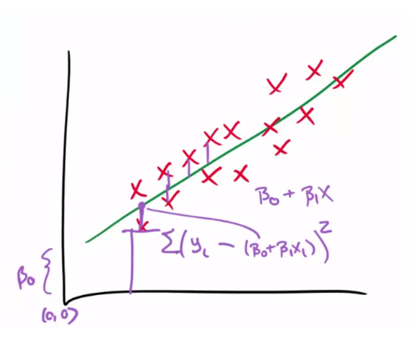

- each of the data point contributes equally to the error between the their locations and the regression line $\rightarrow$ goal of regression is to *minimize* this error

## 5.1 Least Squares Model Fit

- The least squares model fit to the line $Y = \beta_0 + \beta_1 X$ through the data pairs $(X_i, Y_i)$ with $Y_i$ as the outcome obtains the line $Y = \hat \beta_0 + \hat \beta_1 X$ where
  $$\hat \beta_1 = Cor(Y, X) \frac{Sd(Y)}{Sd(X)} ~~~ \hat \beta_0 = \bar Y - \hat \beta_1 \bar X$$
  - [*slope*] $\hat \beta_1$ has the units of $Y / X$
    - $Cor(Y, X)$ = unit-less
    - $Sd(Y)$ = has units of $Y$
    - $Sd(X)$ = has units of $X$
  - [*intercept*] $\hat \beta_0$ has the units of $Y$
  - the line passes through the point $(\bar X, \bar Y$)
    - this is evident from equation for $\beta_0$ (rearrange equation)
- The slope of the regression line with $X$ as the outcome and $Y$ as the predictor is $Cor(Y, X) Sd(X)/ Sd(Y)$
- The slope is the same one you would get if you centered the data, $(X_i - \bar X, Y_i - \bar Y)$, and did a regression through the origin
- If you normalized the data, $\{ \frac{X_i - \bar X}{Sd(X)}, \frac{Y_i - \bar Y}{Sd(Y)}\}$, the slope is $Cor(Y, X)$

## 5.2 Derivation for $\beta_0$ and $\beta_1$

- Let $Y = \beta_0 + \beta_1 X$, and $\hat \beta_0$, $_1 be the $ estimates of $\beta_0$, $\beta_1$, the intercept and slope of the least square regression line, respectively
  $$\begin{aligned}
  we~want~to~minimize~\sum_{i=1}^n (Y_i - \beta_0 - \beta_1 X_i)^2 & = \sum_{i=1}^n (Y_i^* - \beta_0)^2 ~ ~ ~where~ Y_i^* = Y_i - \beta_1 X_i\\
  (solution from 4.1) \sum_{i=1}^n (Y_i^* - \beta_0)^2 & \Rightarrow \hat \beta_0 = \frac{\sum_{i=1}^n Y_i^*}{n} = \frac{\sum_{i=1}^n Y_i - \beta_1 X_i}{n}\\
  & \Rightarrow \hat \beta_0 = \frac{\sum_{i=1}^n Y_i}{n} - \beta_1 \frac{\sum_{i=1}^n X_i}{n}\\
  & \Rightarrow \hat \beta_0 = \bar Y - \beta_1 \bar X\\
  \Longrightarrow \sum_{i=1}^n (Y_i - \beta_0 - \beta_1 X_i)^2 & = \sum_{i=1}^n \left[Y_i - (\bar Y - \beta_1 \bar X) - \beta_1 X_i \right]^2\\
  & = \sum_{i=1}^n \left[(Y_i - \bar Y) - (X_i - \bar X)\beta_1 \right]^2\\
  (this is exactly regression through the origin) & = \sum_{i=1}^n \left[\tilde Y_i - \tilde X_i \beta_1 \right]^2 ~~~ where~ \tilde Y_i = Y_i - \bar Y, \tilde X_i = X_i - \bar X\\
  (solution from 4.1) & \Rightarrow \hat \beta_1 = \frac{\sum_{i=1}^n \tilde Y_i \tilde X_i}{\sum_{i=1}^n \tilde{X_i}^2} = \frac{\sum_{i=1}^n (Y_i - \bar Y)(X_i - \bar X)}{\sum_{i=1}^n (X_i - \bar X)^2}\\
  & \Rightarrow \hat \beta_1 = \frac{\sum_{i=1}^n (Y_i - \bar Y)(X_i - \bar X)/(n-1)}{\sum_{i=1}^n (X_i - \bar X)^2/(n-1)} = \frac{Cov(Y, X)}{Var(X)}\\
  & \Rightarrow \hat \beta_1 = Cor(Y, X) \frac{Sd(Y)}{Sd(X)}\\
  & \Rightarrow \hat \beta_0 = \bar Y - \hat \beta_1 \bar X\\
  \end{aligned}$$

## 5.3 Examples and R Commands

- $\hat \beta_0$ and $\hat \beta_1$ can be manually calculated through the above formulas
- `coef(lm(y ~ x)))` = R command to run the least square regression model on the data with `y` as the outcome, and `x` as the regressor
  - `coef()` = returns the slope and intercept coefficients of the `lm` results

```r
# outcome
y <- galton$child
# regressor
x <- galton$parent
# slope
beta1 <- cor(y, x) * sd(y) / sd(x)
# intercept
beta0 <- mean(y) - beta1 * mean(x)
# results are the same as using the lm command
results <- rbind("manual" = c(beta0, beta1), "lm(y ~ x)" = coef(lm(y ~ x)))
# set column names
colnames(results) <- c("intercept", "slope")
# print results
results
```

```
##           intercept     slope
## manual     23.94153 0.6462906
## lm(y ~ x)  23.94153 0.6462906
```

- slope of the best fit line = slope of best fit line through the origin for centered data
- `lm(y ~ x - 1)` = forces a regression line to go through the origin (0, 0)

```r
### Regression through the origin yields an equivalent slope if you center the data first
# centering y
yc <- y - mean(y)
# centering x
xc <- x - mean(x)
# slope
beta1 <- sum(yc * xc) / sum(xc ^ 2)
# results are the same as using the lm command
results <- rbind("centered data (manual)" = beta1, "lm(y ~ x)" = coef(lm(y ~ x))[2],
    "lm(yc ~ xc - 1)" = coef(lm(yc ~ xc - 1))[1])
# set column names
colnames(results) <- c("slope")
# print results
results
```

```
##                            slope
## centered data (manual) 0.6462906
## lm(y ~ x)              0.6462906
## lm(yc ~ xc - 1)        0.6462906
```

- slope of best fit line for normalized data = $Cor(Y, X)$

```r
### Normalizing variables results in the slope being the correlation
# normalize y
yn <- (y - mean(y))/sd(y)
# normalize x
xn <- (x - mean(x))/sd(x)
# compare correlations
results <- rbind("cor(y, x)" = cor(y, x), "cor(yn, xn)" = cor(yn, xn),
    "slope" = coef(lm(yn ~ xn))[2])
# print results
results
```

```
##                    xn
## cor(y, x)   0.4587624
## cor(yn, xn) 0.4587624
## slope       0.4587624
```

- `geom_smooth(method = "lm", formula = y~x)` function in `ggplot2` = adds regression line and confidence interval to graph
  - `formula = y~x` = default for the line (argument can be eliminated if `y~x` produces the line you want)

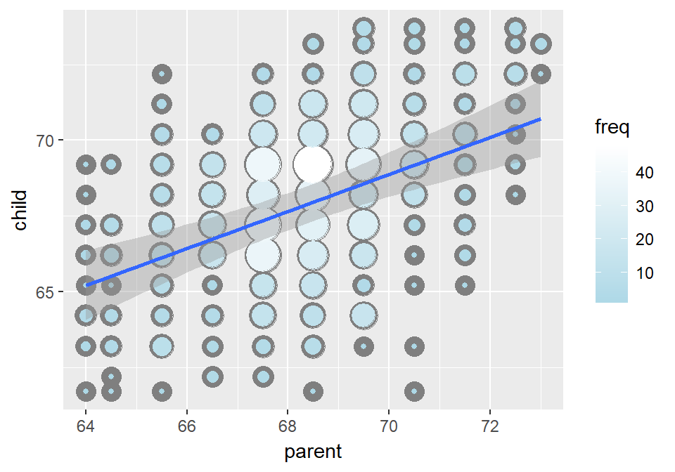

```r
# constructs table for different combination of parent-child height
freqData <- as.data.frame(table(galton$child, galton$parent))
names(freqData) <- c("child (in)", "parent (in)", "freq")
# convert to numeric values
freqData$child <- as.numeric(as.character(freqData$child))
freqData$parent <- as.numeric(as.character(freqData$parent))
g <- ggplot(filter(freqData, freq > 0), aes(x = parent, y = child))
g <- g + scale_size(range = c(1, 10), guide = "none" )
g <- g + geom_point(colour="grey50", aes(size = freq+10))
g <- g + geom_point(aes(colour=freq, size = freq))
g <- g + scale_colour_gradient(low = "lightblue", high="white")
g <- g + geom_smooth(method="lm", formula=y~x)
g
```

# 6 Regression to the Mean

- first investigated by Francis Galton in the paper *“Regression towards mediocrity in hereditary stature” The Journal of the Anthropological Institute of Great Britain and Ireland , Vol. 15, (1886)*
- **regression to the mean** was invented by Fancis Galton to capture the following phenomena
  - children of tall parents tend to be tall, but not as tall as their parents
  - children of short parents tend to be short, but not as short as their parents
  - parents of very short children, tend to be short, but not as short as their child
  - parents of very tall children, tend to be tall, but not as tall as their children
- Think of it this way, imagine if you simulated pairs or random normals
  - The largest first ones would be the largest by chance, and the probability that there are smaller for the second simulation is high.
  - In other words $P(Y < x | X = x)$ gets bigger as $x$ heads to very large values
    - or, given that the value of X is already very large (extreme), the chance that the value of Y is as large or larger than that of X is small (unlikely)
  - similarly, $P(Y > x | X = x)$ gets bigger as $x$ heads to very small values
    - or, given that the value of X is already very small (extreme), the chance that the value of Y is as small or smaller than that of X is small (unlikely)
- when constructing regression lines between $X$ and $Y$, the line represents the intrinsic relationship (“mean”) between the variables, but does not capture the extremes (“noise”)
  - unless $Cor(Y, X) = 1$, the regression line or the intrinsic part of the relationship between variables won’t capture all of the variation (some noise exists)

## 6.1 Galton’s Investigation on Regression to the Mean

- both $X$, child’s heights, and $Y$, parent’s heights, are **normalized** so that they have mean of 0 and variance of 1
- regression lines must pass $(\bar X, \bar Y)$ or $(0, 0)$ in this case
- slope of regression line = $Cor(Y,X)$ regardless of which variable is the outcome or regressor (because standard deviations of both variables = 1)
- Notice if $X$ is the outcome and you create a plot where $X$ is the horizontal axis, the slope of the least squares line that you plot is $1/Cor(Y, X)$.
  - **Note**: for both regression lines to be plotted on the same graph, the second line’s slope must be $1/Cor(Y, X)$ because the two relationships have flipped axes

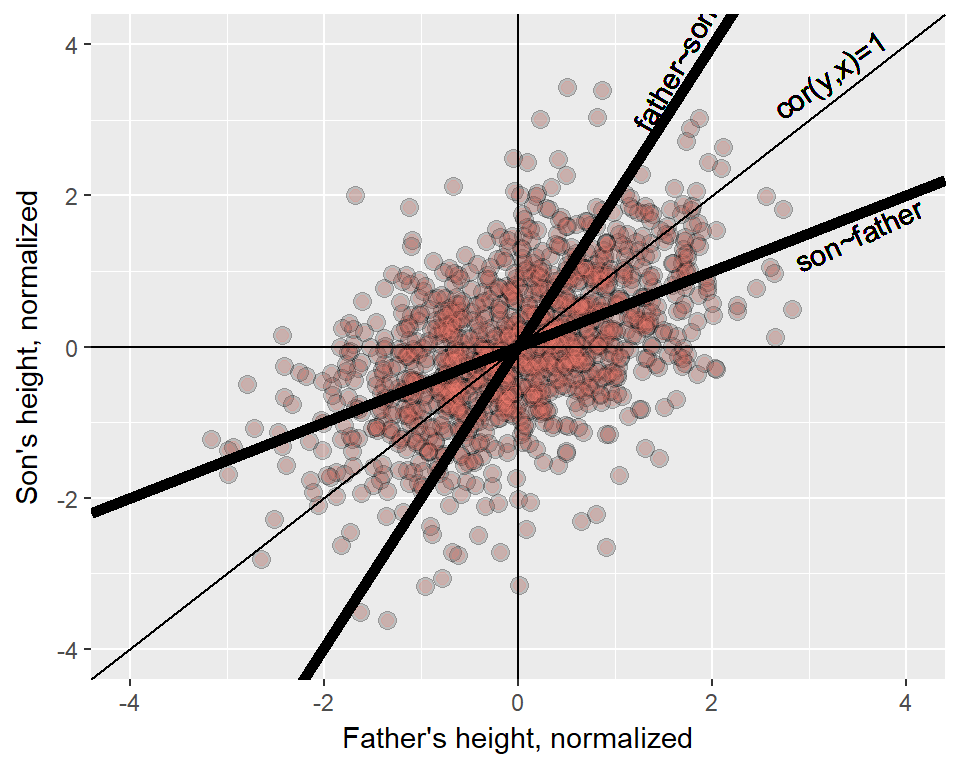

```r
# load father.son data
data(father.son)
# normalize son's height
y <- (father.son$sheight - mean(father.son$sheight)) / sd(father.son$sheight)
# normalize father's height
x <- (father.son$fheight - mean(father.son$fheight)) / sd(father.son$fheight)
# calculate correlation
rho <- cor(x, y)
# plot the relationship between the two
g = ggplot(data.frame(x = x, y = y), aes(x = x, y = y))
g = g + geom_point(size = 3, alpha = .2, colour = "black")
g = g + geom_point(size = 2, alpha = .2, colour = "salmon")
g = g + xlim(-4, 4) + ylim(-4, 4)
# reference line for perfect correlation between
# variables (data points will like on diagonal line)
g = g + geom_abline()
# if there is no correlation between the two variables,
# the data points will lie on horizontal/vertical lines
g = g + geom_vline(xintercept = 0)
g = g + geom_hline(yintercept = 0)
# plot the actual correlation for both
g = g + geom_abline(intercept = 0, slope = rho, size = 2)
g = g + geom_abline(intercept = 0, slope = 1 / rho, size = 2)
# add appropriate labels
g = g + xlab("Father's height, normalized")
g = g + ylab("Son's height, normalized")
g = g + geom_text(x = 3.5, y = 1.5, label="son~father", angle = 25) +
    geom_text(x = 3.2, y = 3.6, label="cor(y,x)=1", angle = 35) +
    geom_text(x = 1.6, y = 3.7, label="father~son", angle = 60)
g
```

- suppose $x$ (father’s height) is 2, then multiplying it with the correlation (which is the regression slope of the normalized data) is the **regression of the mean**
  - how shrunken this correlation is towards the horizontal line (from the line of perfect correlation) gives you the extent of the regression to the mean

# 7 Statistical Linear Regression Models

- goal is use statistics to draw inferences $\rightarrow$ generalize from data to population through models
- **probabilistic model for linear regression**
  $$Y_i = \beta_0 + \beta_1 X_i + \epsilon_{i}$$
  where $\epsilon_{i}$ represents the sampling errors and is assumed to be iid $N(0, \sigma^2)$
- this model has the following properties
  - $E[Y_i ~|~ X_i = x_i] = E[\beta_0] + E[\beta_1 x_i] + E[\epsilon_{i}] = \mu_i = \beta_0 + \beta_1 x_i$
  - $Var(Y_i ~|~ X_i = x_i) = Var(\beta_0 + \beta_1 x_i) + Var(\epsilon_{i}) = Var(\epsilon_{i}) = \sigma^2$
    - $\beta_0 + \beta_1 x_i$ = line = constant/no variance
- it can then be said to have $Y_i$ as independent $N(\mu, \sigma^2)$, where $\mu = \beta_0 + \beta_1 x_i$ <– likelihood equivalent model
  - **likelihood** = given the outcome, what is the probability?
    - in this case, the likelihood is as follows
      $$\mathcal{L}(\beta_0, \beta_1, \sigma) = \prod_{i=1}^{n} \left\{(2\pi \sigma^2)^{-1/2}\exp \left(- \frac{1}{2\sigma^2}(y_i - \mu_i)^2\right)\right\}$$
      where $\mu_i = \beta_0 + \beta_1 x_i$
    - above is the **probability density function** of $n$ samples from the normal distribution $\rightarrow$ this is because the regression line is normally distributed due to $\epsilon_{i}$
  - **maximum likelihood estimator (MLE)** = most likely estimate of the population parameter/probability
    - in this case, the maximum likelihood = -2 minimum natural log ($ln$, base $e$) likelihood
      $$-2 \log{\mathcal{L}(\beta_0, \beta_1, \sigma)} = n\log(2\pi \sigma^2) + \frac{1}{\sigma^2}\sum_{i=1}^n (y_i - \mu_i)^2$$
      - since everything else is constant, minimizing this function would only depend on $\sum_{i=1}^n (y_i - \mu_i)^2$, which from our previous derivations yields $\hat \mu_i = \beta_0 + \beta_1 \hat x_i$
    - *maximum likelihood estimate* = $\mu_i = \beta_0 + \beta_1 x_i$

## 7.1 Interpreting Regression Coefficients

- for the linear regression line
  $$Y_i = \beta_0 + \beta_1 X_i + \epsilon_{i}$$
  MLE for $\beta_0$ and $\beta_1$ are as follows
  $$\hat \beta_1 = Cor(Y, X)\frac{Sd(Y)}{Sd(X)} ~~~ \hat \beta_0 = \bar Y - \hat \beta_1 \bar X$$
- **$\beta_0$** = expected value of the outcome/response when the predictor is 0
  $$E[Y | X = 0] = \beta_0 + \beta_1 \times 0 = \beta_0$$
  - **Note**: $X=0$ may not always be of interest as it may be impossible/outside of data range (i.e blood pressure, height etc.)
  - it may be useful to move the intercept at times
    $$\begin{aligned}
    Y_i &= \beta_0 + \beta_1 X_i + \epsilon_i\\
    &= \beta_0 + a \beta_1 + \beta_1 (X_i - a) + \epsilon_i \\
    &= \tilde \beta_0 + \beta_1 (X_i - a) + \epsilon_i ~ ~ ~ ~ where \tilde \beta_0 = \beta_0 + a \beta_1\\
    \end{aligned}$$
  - **Note**: shifting $X$ values by value $a$ changes the intercept, but not the slope
  - often, $a$ is set to $\bar X$ so that the intercept is interpreted as the expected response at the average $X$ value
- **$\beta_1$** = expected change in outcome/response for a 1 unit change in the predictor
  $$E[Y ~|~ X = x+1] - E[Y ~|~ X = x] =
  \beta_0 + \beta_1 (x + 1) - (\beta_0 + \beta_1 x ) = \beta_1$$
  - sometimes it is useful to change the units of $X$
    $$\begin{aligned}
    Y_i & = \beta_0 + \beta_1 X_i + \epsilon_i \\
    & = \beta_0 + \frac{\beta_1}{a} (X_i a) + \epsilon_i \\
    & = \beta_0 + \tilde \beta_1 (X_i a) + \epsilon_i \\
    \end{aligned}$$
  - multiplication of $X$ by a factor $a$ results in dividing the coefficient by a factor of $a$
  - *Example*:
    - $X$ = height in $m$
    - $Y$ = weight in $kg$
    - $\beta_1$ has units of $kg/m$
    - converting $X$ to $cm$ $\Longrightarrow$ multiplying $X$ by $100 \frac{cm}{m}$
    - this mean $\beta_1$ has to be divided by $100 \frac{cm}{m}$ for the correct units.
      $$Xm \times 100\frac{cm}{m} = (100~X) cm
      ~~\mbox{and}~~
      \beta_1 \frac{kg}{m} \times \frac{1}{100}\frac{m}{cm} = \left(\frac{\beta_1}{100}\right)\frac{kg}{cm}$$
- 95% confidence intervals for the coefficients can be constructed from the coefficients themselves and their standard errors (from `summary(lm)`)
  - use the resulting intervals to evaluate the significance of the results

## 7.2 Use Regression Coefficients for Prediction

- for observed values of the predictor, $X_1, X_2, \ldots , X_n$, the prediction of the outcome/response is as follows
  $$\hat \mu_i = \hat Y_i = \hat \beta_0 + \hat \beta_1 X$$
  where $\mu_i$ describes a point on the regression line

## 7.3 Example and R Commands

- `diamond` dataset from `UsingR` package
  - diamond prices in Singapore Dollars, diamond weight in carats (standard measure of diamond mass, 0.2g)
- `lm(price ~ I(carat - mean(carat)), data=diamond)` = mean centered linear regression
  - **Note**: arithmetic operations must be enclosed in `I()` to work
- `predict(fitModel, newdata=data.frame(carat=c(0, 1, 2)))` = returns predicted outcome from the given model (linear in our case) at the provided points within the `newdata` data frame
  - if `newdata` is unspecified (argument omitted), then `predict` function will return predicted values for all observed values of the predictor (x variable, carat in this case)
    - **Note**: `newdata` has to be a dataframe, and the values you would like to predict (x variable, `carat` in this case) has to be specified, or the system won’t know what to do with the provided values
- `summary(fitModel)` = prints detailed summary of linear model

```r
library(UsingR)
data(diamond)
# standard linear regression for price vs carat
fit <- lm(price ~ carat, data = diamond)
# intercept and slope
coef(fit)
```

```
## (Intercept)       carat
##   -259.6259   3721.0249
```

```r
# mean-centered regression
fit2 <- lm(price ~ I(carat - mean(carat)), data = diamond)
# intercept and slope
coef(fit2)
```

```
##            (Intercept) I(carat - mean(carat))
##               500.0833              3721.0249
```

```r
# regression with more granular scale (1/10th carat)
fit3 <- lm(price ~ I(carat * 10), data = diamond)
# intercept and slope
coef(fit3)
```

```
##   (Intercept) I(carat * 10)
##     -259.6259      372.1025
```

```r
# predictions for 3 values
newx <- c(0.16, 0.27, 0.34)
# manual calculations
coef(fit)[1] + coef(fit)[2] * newx
```

```
## [1]  335.7381  745.0508 1005.5225
```

```r
# prediction using the predict function
predict(fit, newdata = data.frame(carat = newx))
```

```
##         1         2         3
##  335.7381  745.0508 1005.5225
```

- **interpretation**
  - Standard linear regression
    - we estimate an expected 3721.02 (SIN) dollar increase in price for *every carat increase* in mass of diamond
    - the intercept -259.63 is the expected price of a 0 carat diamond (not very interesting)
  - Mean-centered regression
    - $500.1 is the expected price for the average sized diamond of the data (0.2042 carats)
  - Regression with more granular scale (1/10th carat)
    - 372.1 (SIN) dollar increase in price for *every 1/10 carat* increase in mass of diamond
- **prediction**
  - for 0.16, 0.27, and 0.34 carats, we predict the prices to be 335.74, 745.05, 1005.52 (SIN) dollars

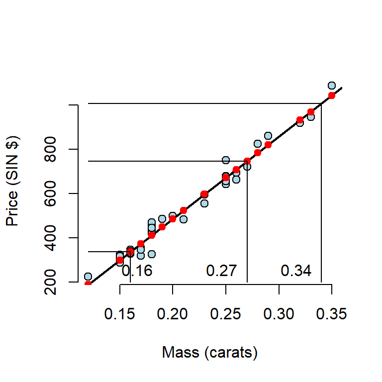

```r
# plot the data points
plot(diamond$carat, diamond$price, xlab = "Mass (carats)", ylab = "Price (SIN $)",
     bg = "lightblue", col = "black", cex = 1.1, pch = 21,frame = FALSE)
# plot linear regression line
abline(fit, lwd = 2)
# plot predictions for every value of carat (in red)
points(diamond$carat, predict(fit), pch = 19, col = "red")
# add guidelines for predictions for 0.16, 0.27, and 0.34
lines(c(0.16, 0.16, 0.12), c(200, coef(fit)[1] + coef(fit)[2] * 0.16,
      coef(fit)[1] + coef(fit)[2] * 0.16))
lines(c(0.27, 0.27, 0.12), c(200, coef(fit)[1] + coef(fit)[2] * 0.27,
      coef(fit)[1] + coef(fit)[2] * 0.27))
lines(c(0.34, 0.34, 0.12), c(200, coef(fit)[1] + coef(fit)[2] * 0.34,
      coef(fit)[1] + coef(fit)[2] * 0.34))
# add text labels
text(newx+c(0.03, 0, 0), rep(250, 3), labels = newx, pos = 2)
```

## 7.4 Derivation for Maximum Likelihood Estimator

- **Note**: this derivation is for the maximum likelihood estimator of the mean, $\mu$, of a normal distribution as it is the basis of the linear regression model
- **linear regression model**
  $$Y_i = \beta_0 + \beta_1 X_i + \epsilon_{i}$$
  follows a normal distribution because $\epsilon_{i} \sim N(0, \sigma^2)$
- for the above model, $E[Y_i] = \mu_i = \beta_0 + \beta_1 X_i$ and $Var(Y_i) = \sigma^2$

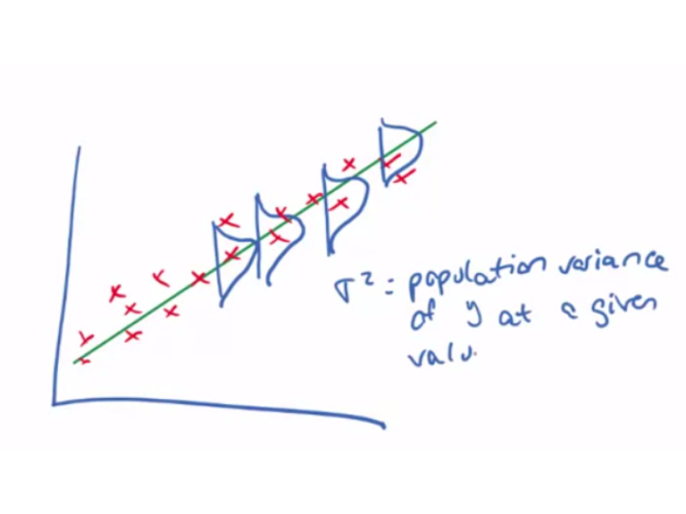

- the **probability density function (pdf)** for an outcome $x$ from the normal distribution is defined as
  $$f(x~|~\mu, \sigma^2) = (2\pi \sigma^2)^{-1/2}\exp \left(- \frac{1}{2\sigma^2}(y_i - \mu_i)^2\right)$$
- the corresponding pdf for $n$ iid normal random outcomes $x_1, \ldots, x_n$ is defined as
  $$f(x_1, \ldots, x_n~|~\mu, \sigma^2) = \prod_{i=1}^n (2\pi \sigma^2)^{-1/2}\exp \left(- \frac{1}{2\sigma^2}(y_i - \mu_i)^2\right)$$
  which is also known as the **likelihood function**, denoted in this case as $\mathcal{L}(\mu, \sigma)$
- to find the **maximum likelihood estimator (MLE)** of the mean, $\mu$, we take the derivative of the likelihood $\mathcal{L}$ with respect to $\mu$ $\rightarrow$ $\frac{\partial \mathcal{L}}{\partial \mu}$
- since derivatives of products are quite complex to compute, taking the $\log$ (base $e$) makes the calculation much simpler
  - $\log$ properties:
    - $\log(AB) = \log(A) + \log(B)$
    - $\log(A^B) = B\log(A)$
  - because $\log$ is always increasing and **monotonic**, or preserves order, finding the maximum MLE **=** finding th maximum of $\log$ transformation of MLE
- -2 $\log$ of **likelihood function**
  $$\begin{aligned}
  \log(\mathcal{L}(\mu, \sigma)) & = \sum_{i=1}^n -\frac{1}{2}\log(2\pi \sigma^2) - \frac{1}{2\sigma^2}(y_i - \mu_i)^2 \Leftarrow \mbox{multiply -2 on both sides} \\
  -2\log(\mathcal{L}(\mu, \sigma)) & = \sum_{i=1}^n \log(2\pi \sigma^2) + \frac{1}{\sigma^2}(y_i - \mu_i)^2 \Leftarrow \sigma^2 \mbox{ does not depend on }i \\
  -2\log(\mathcal{L}(\mu, \sigma)) & = n\log(2\pi \sigma^2) + \frac{1}{\sigma^2}\sum_{i=1}^n (y_i - \mu_i)^2\\
  \end{aligned}$$
- minimizing -2 $\log$ likelihood is *computationally equivalent* as maximizing $\log$ likelihood
  $$\begin{aligned}
  \frac{\partial \log(\mathcal{L}(\mu, \sigma))}{\partial \mu} & = \frac{1}{\sigma^2} \frac{\partial \sum_{i=1}^n (y_i - \mu_i)^2}{\partial \mu} = 0 \Leftarrow \mbox{setting this equal to 0 to find minimum}\\
  \Rightarrow -\frac{2}{\sigma^2}\sum_{i=1}^n (y_i - \mu_i) & = 0 \Leftarrow \mbox{divide by }-2/\sigma^2 \mbox{ on both sides}\\
  \sum_{i=1}^n (y_i - \mu_i) & = 0 \Leftarrow \mbox{move } \mu \mbox{ term over to the right}\\
  \sum_{i=1}^n y_i & = \sum_{i=1}^n \mu_i \Leftarrow \mbox{for the two sums to be equal, all the terms must be equal}\\
  y_i & = \mu_i \\
  \end{aligned}$$
- in the case of our linear regression, $\mu_i = \beta_0 + \beta_1 X_i$ so
  $$\begin{aligned}
  \frac{\partial \mathcal{L}(\mu, \sigma))}{\partial \mu} = \frac{\partial \mathcal{L}(\beta_0, \beta_1, \sigma))}{\partial \mu} \\
  \mbox{MLE} \Rightarrow Y_i & = \mu_i \\
  \mu_i &= \beta_0 + \beta_1 X_i\\
  \end{aligned}$$

# 8 Residuals

- **Intro**: Residuals represent variation left unexplained by our model. We emphasize the difference between residuals and errors. The errors are unobservable true errors from the known coefficients, while residuals are the observable errors from the estimated coefficients. In a sense, the residuals are estimates of the errors.
- Residual, $e_i$ = difference between the observed and predicted outcome
  $$e_i = Y_i - \hat Y_i$$
  - Or, vertical distance between observed data point and regression line
  - Least squares minimizes $\sum_{i=1}^n e_i^2$
- $e_i$ can be interpreted as estimates of the regression error, $\epsilon_i$
- $e_i$ can also be interpreted as the outcome ($Y$) with the linear association of the predictor ($X$) removed
  - or, “Y adjusted for X”
- $E[e_i] = 0$ $\rightarrow$ this is because the mean of the residuals is expected to be 0 (assumed Gaussian distribution)
  - the Gaussian distribution assumption also implies that the error is **NOT** correlated with any predictors
  - `mean(fitModel$residuals)` = returns mean of residuals $\rightarrow$ should equal to 0
  - `cov(fit$residuals, predictors)` = returns the covariance (measures correlation) of residuals and predictors $\rightarrow$ should also equal to 0
- $\sum_{i=1}^n e_i = 0$ (if an intercept is included) and $\sum_{i=1}^n e_i X_i = 0$ (if a regressor variable $X_i$ is included)
- for standard linear regression model
  - positive residuals = above the line
  - negative residuals = below
- residuals and residual plots can highlight poor model fit
- one needs to differentiate residual variation (variation after removing the predictor) from systematic varation (variation explained by the regression model)

## 8.1 Estimating Residual Variation

- residual variation measures how well the regression line fit the data points
- **MLE of variance**, $\sigma^2$, of the linear model = $\frac{1}{n}\sum_{i=1}^n e_i^2$ or the *average squared residual/mean squared error*
  - the square root of the estimate, $\sigma$, = **root mean squared error (RMSE)**
- however, a more common approach is to use
  $$\hat \sigma^2 = \frac{1}{n-2}\sum_{i=1}^n e_i^2$$
  - $n-2$ is used instead of $n$ to make the estimator *unbiased* $\rightarrow$ $E[\hat \sigma^2] = \sigma^2$
  - **Note**: the -2 is accounting for the degrees of freedom for intercept and slope, which had to be estimated
- `deviance(fitModel)` = calculates sum of the squared error/residual for the linear model/**residual variation**
- `summary(fitModel)$sigma` = returns the residual variation of a fit model or the **unbiased RMSE**
  - `summary(fitModel)` = creates a list of different parameters of the fit model

```r
# get data
y <- diamond$price; x <- diamond$carat; n <- length(y)
# linear fit
fit <- lm(y ~ x)
# calculate residual standard error through summary and manually
rbind("from summary" = summary(fit)$sigma, "manual" =sqrt(sum(resid(fit)^2) / (n - 2)))
```

```
##                  [,1]
## from summary 31.84052
## manual       31.84052
```

## 8.2 Total Variation, $R^2$, and Derivations

- **total variation** = *residual variation* (variation after removing predictor, not explained by the model) + *systematic/regression variation* (variation explained by regression model)
  $$\sum_{i=1}^n (Y_i - \bar Y)^2 = \sum_{i=1}^n (Y_i - \hat Y_i)^2 + \sum_{i=1}^n (\hat Y_i - \bar Y)^2$$
- $R^2$ = percent of total variability that is explained by the regression model
  $$\begin{aligned}
  R^2 & = \frac{\mbox{regression variation}}{\mbox{total variation}} = \frac{\sum_{i=1}^n (\hat Y_i - \bar Y)^2}{\sum_{i=1}^n (Y_i - \bar Y)^2} \\
  & = 1- \frac{\mbox{residual variation}}{\mbox{total variation}} = 1- \frac{\sum_{i=1}^n (Y_i - \hat Y_i)^2}{\sum_{i=1}^n (Y_i - \bar Y)^2}\\
  \end{aligned}$$
- $0 \leq R^2 \leq 1$
- $R^2$ = sample correlation squared
  - `cor(outcome, predictor` = calculates the correlation between predictor and outcome $\rightarrow$ the same as calculating $R^2$
- $R^2$ can be a *misleading* summary of model fit
  - deleting data $\rightarrow$ inflate $R^2$
  - adding terms to a regression model $\rightarrow$ always increases $R^2$
  - `data(anscombe); example(anscombe)` demonstrates the fallacy of $R^2$ through the following
    - basically same mean and variance of X and Y
    - identical correlations (hence same $R^2$)
    - same linear regression relationship

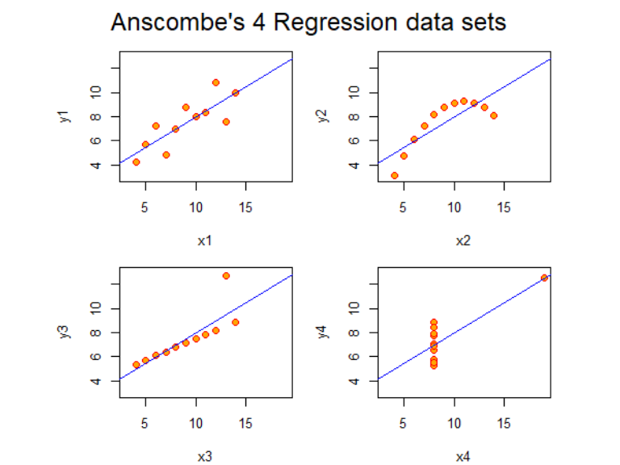

- **relationship between $R^2$ and $r$**
  $$\begin{aligned}
  \mbox{Correlation between X and Y} \Rightarrow r & = Cor(Y, X)\\
  R^2 & = \frac{\sum_{i=1}^n (\hat Y_i - \bar Y)^2}{\sum_{i=1}^n (Y_i - \bar Y)^2} \\
  &recall \Rightarrow (\hat Y_i - \bar Y) = \hat \beta_1 (X_i - \bar X)\\
  (substituting (\hat Y_i - \bar Y)) & = \hat \beta_1^2 \frac{\sum_{i=1}^n(X_i - \bar X)^2}{\sum_{i=1}^n (Y_i - \bar Y)^2}\\
  &recall \Rightarrow \hat \beta_1 = Cor(Y, X)\frac{Sd(Y)}{Sd(X)}\\
  (substituting \hat \beta_1) & = Cor(Y, X)^2\frac{Var(Y)}{Var(X)} \times \frac{\sum_{i=1}^n(X_i - \bar X)^2}{\sum_{i=1}^n (Y_i - \bar Y)^2}\\
  & recall ~ Var(Y) = \sum_{i=1}^n (Y_i - \bar Y)^2 ~ and ~ Var(X) = \sum_{i=1}^n (X_i - \bar X)^2\\
  (simplifying) \Rightarrow R^2 &= Cor(Y,X)^2\\
  \mbox{Or } R^2 & = r^2\\
  \end{aligned}$$
- *total variation derivation*
  $$\begin{aligned}
  \mbox{First, we know that } \bar Y & = \hat \beta_0 + \hat \beta_1 \bar X \\
  (transforming) \Rightarrow \hat \beta_0 & = \bar Y - \hat \beta_1 \bar X \\
  \\
  \mbox{We also know that } \hat Y_i & = \hat \beta_0 + \hat \beta_1 X_i \\
  \\
  \mbox{Next, the residual } = (Y_i - \hat Y_i) & = Y_i - \hat \beta_0 - \hat \beta_1 X_i \\
  (substituting~\hat \beta_0) & = Y_i - (\bar Y - \hat \beta_1 \bar X) - \hat \beta_1 X_i \\
  (transforming) \Rightarrow (Y_i - \hat Y_i) & = (Y_i - \bar Y) - \hat \beta_1 (X_i - \bar X) \\
  \\
  \mbox{Next, the regression difference } = (\hat Y_i - \bar Y) & = \hat \beta_0 - \hat \beta_1 X_i -\bar Y \\
  (substituting~\hat \beta_0) & = \bar Y - \hat \beta_1 \bar X - \hat \beta_1 X_i - \bar Y \\
  (transforming) \Rightarrow (\hat Y_i - \bar Y) & = \hat \beta_1 (X_i - \bar X) \\
  \\
  \mbox{Total Variation} = \sum_{i=1}^n (Y_i - \bar Y)^2 & = \sum_{i=1}^n (Y_i - \hat Y_i + \hat Y_i - \bar Y)^2 \Leftarrow (adding~\pm \hat Y_i) \\
  (expanding) & = \sum_{i=1}^n (Y_i - \hat Y_i)^2 + 2 \sum_{i=1}^n (Y_i - \hat Y_i)(\hat Y_i - \bar Y) + \sum_{i=1}^n (\hat Y_i - \bar Y)^2 \\
  \\
  \mbox{Looking at } \sum_{i=1}^n (Y_i - \hat Y_i)(\hat Y_i - \bar Y) & \\
  (substituting~(Y_i - \hat Y_i),(\hat Y_i - \bar Y)) &= \sum_{i=1}^n \left[(Y_i - \bar Y) - \hat \beta_1 (X_i - \bar X))\right]\left[\hat \beta_1 (X_i - \bar X)\right]\\
  (expanding) & = \hat \beta_1 \sum_{i=1}^n (Y_i - \bar Y)(X_i - \bar X) -\hat\beta_1^2\sum_{i=1}^n (X_i - \bar X)^2\\
  & (substituting~Y_i, \bar Y) \Rightarrow (Y_i - \bar Y) = (\hat \beta_0 + \hat \beta_1 X_i) - (\hat \beta_0 + \hat \beta_1 \bar X) \\
  & (simplifying) \Rightarrow (Y_i - \bar Y) = \hat \beta_1 (X_i - \bar X) \\
  (substituting~(Y_i - \bar Y)) & = \hat \beta_1^2 \sum_{i=1}^n (X_i - \bar X)^2-\hat\beta_1^2\sum_{i=1}^n (X_i - \bar X)^2\\
  \Rightarrow \sum_{i=1}^n (Y_i - \hat Y_i)(\hat Y_i - \bar Y) &= 0 \\
  \\
  \mbox{Going back to} \sum_{i=1}^n (Y_i - \bar Y)^2 &= \sum_{i=1}^n (Y_i - \hat Y_i)^2 + 2 \sum_{i=1}^n (Y_i - \hat Y_i)(\hat Y_i - \bar Y) + \sum_{i=1}^n (\hat Y_i - \bar Y)^2 \\
  (since~second~term= 0) \Rightarrow \sum_{i=1}^n (Y_i - \bar Y)^2 &= \sum_{i=1}^n (Y_i - \hat Y_i)^2 + \sum_{i=1}^n (\hat Y_i - \bar Y)^2\\
  \end{aligned}$$

## 8.3 Examples and R Commands

- `resid(fitModel)` or `fitModel$residuals` = extracts model residuals from the fit model (lm in our case) $\rightarrow$ list of residual values for every value of X
- `summary(fitModel)$r.squared` = return $R^2$ value of the regression model

```r
# load multiplot function
source("./scripts/multiplot.R")
# get data
y <- diamond$price; x <- diamond$carat; n <- length(y)
# linear regression
fit <- lm(y ~ x)
# calculate residual
e <- resid(fit)
# calculate predicted values
yhat <- predict(fit)
# show that residuals are the differences between y and yhat
max(abs(e - (y - yhat)))
```

```
## [1] 9.485746e-13
```

```r
# show that sum of residuals and
# sum of residuals times regressor equals 0
rbind("sum(e)" = sum(e), "sum(e*x)" = sum(e*x))
```

```
##                   [,1]
## sum(e)   -1.865175e-14
## sum(e*x)  6.959711e-15
```

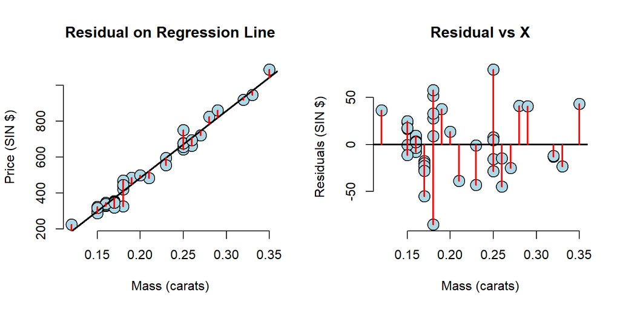

```r
# create 1 x 2 panel plot
par(mfrow=c(1, 2))
# plot residuals on regression line
plot(x, y, xlab = "Mass (carats)", ylab = "Price (SIN $)", bg = "lightblue",
    col = "black", cex = 2, pch = 21,frame = FALSE,main = "Residual on Regression Line")
# draw linear regression line
abline(fit, lwd = 2)
# draw red lines from data points to regression line
for (i in 1 : n){lines(c(x[i], x[i]), c(y[i], yhat[i]), col = "red" , lwd = 2)}
# plot residual vs x
plot(x, e, xlab = "Mass (carats)", ylab = "Residuals (SIN $)", bg = "lightblue",
    col = "black", cex = 2, pch = 21,frame = FALSE,main = "Residual vs X")
# draw horizontal line
abline(h = 0, lwd = 2)
# draw red lines from residual to x axis
for (i in 1 : n){lines(c(x[i], x[i]), c(e[i], 0), col = "red" , lwd = 2)}
```

- Non-linear data/patterns can be more easily revealed through residual plots

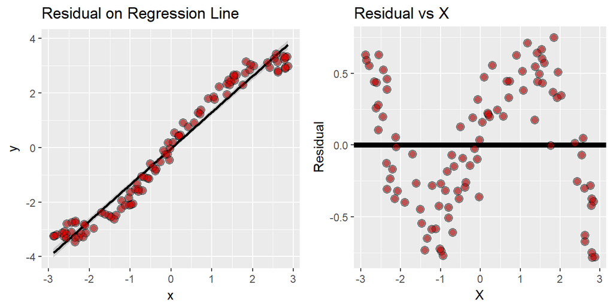

```r
# create sin wave pattern
x <- runif(100, -3, 3); y <- x + sin(x) + rnorm(100, sd = .2);
# plot data + regression
g <- ggplot(data.frame(x = x, y = y), aes(x = x, y = y)) +
    geom_smooth(method = "lm", colour = "black") +
    geom_point(size = 3, colour = "black", alpha = 0.4) +
    geom_point(size = 2, colour = "red", alpha = 0.4)+
 ggtitle("Residual on Regression Line")
# plot residuals
f <- ggplot(data.frame(x = x, y = resid(lm(y ~ x))), aes(x = x, y = y))+
    geom_hline(yintercept = 0, size = 2)+
    geom_point(size = 3, colour = "black", alpha = 0.4)+
    geom_point(size = 2, colour = "red", alpha = 0.4)+
    xlab("X") + ylab("Residual")+ ggtitle("Residual vs X")
multiplot(g, f, cols = 2)
```

- **Heteroskedasticity** = heteroskedastic model’s variance is not constant and is a function of x

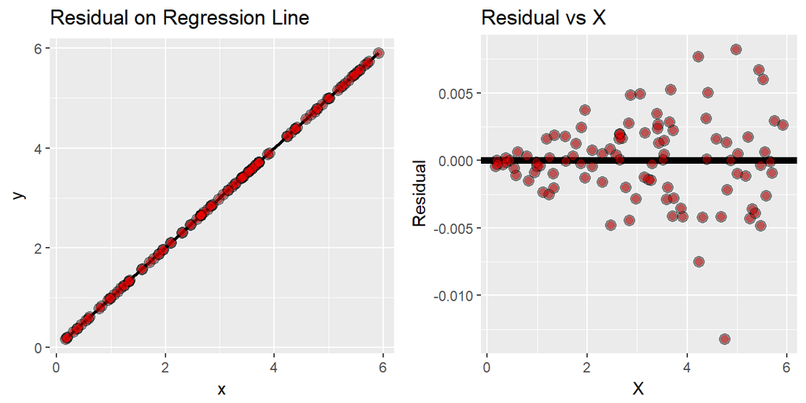

```r
# create heteroskedastic data
x <- runif(100, 0, 6); y <- x + rnorm(100,  mean = 0, sd = .001 * x)
# plot data + regression
g <- ggplot(data.frame(x = x, y = y), aes(x = x, y = y))+
 geom_smooth(method = "lm", colour = "black")+
 geom_point(size = 3, colour = "black", alpha = 0.4)+
 geom_point(size = 2, colour = "red", alpha = 0.4) +
 ggtitle("Residual on Regression Line")
# plot residuals
f <- ggplot(data.frame(x = x, y = resid(lm(y ~ x))), aes(x = x, y = y))+
           geom_hline(yintercept = 0, size = 2) +
           geom_point(size = 3, colour = "black", alpha = 0.4)+
           geom_point(size = 2, colour = "red", alpha = 0.4)+
           xlab("X") + ylab("Residual") + ggtitle("Residual vs X")
# combine two plots
multiplot(g, f, cols = 2)
```

- Diamond Residual plots using ggplot

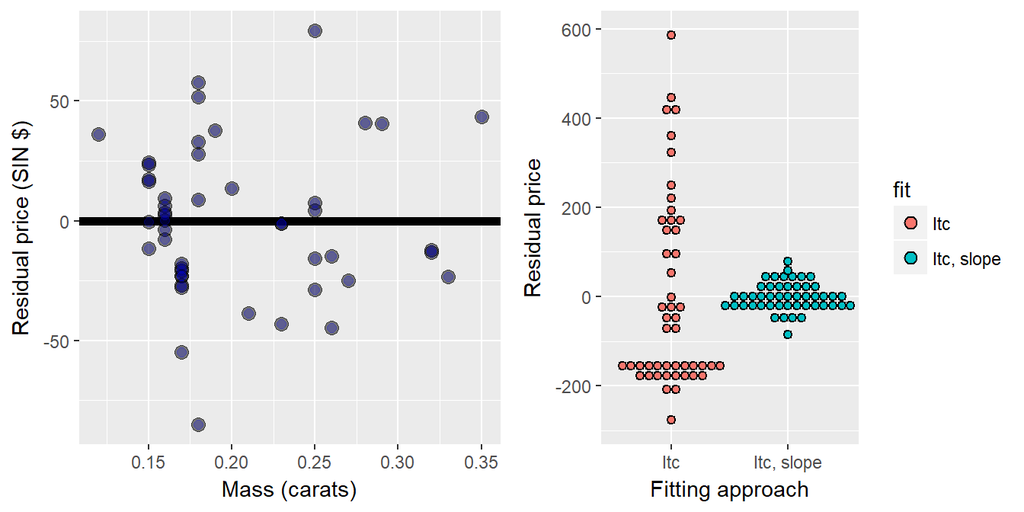

```r
# plot residuals using ggplot
diamond$e <- resid(lm(price ~ carat, data = diamond))
g = ggplot(diamond, aes(x = carat, y = e))
g = g + xlab("Mass (carats)")
g = g + ylab("Residual price (SIN $)")
g = g + geom_hline(yintercept = 0, size = 2)
g = g + geom_point(size = 3, colour = "black", alpha=0.5)
g = g + geom_point(size = 2, colour = "blue", alpha=0.2)

# Create 2 residual vectors:
# FIRST residual vector is just a fit with an intercept
# So the residuals are just the deviations around the average price
# SECOND vector is the residuals around the regression line
# with carats as the explanatory variable
e = c(resid(lm(price ~ 1, data = diamond)),
      resid(lm(price ~ carat, data = diamond)))
fit = factor(c(rep("Itc", nrow(diamond)),
               rep("Itc, slope", nrow(diamond))))
f = ggplot(data.frame(e = e, fit = fit), aes(y = e, x = fit, fill = fit))
f = f + geom_dotplot(binaxis = "y", size = 2, stackdir = "center", binwidth = 20)
f = f + xlab("Fitting approach")
f = f + ylab("Residual price")

multiplot(g, f, cols = 2)
```

- **Note**: The intercept is really the coefficient of a special regressor which has the same value, 1, at every sample.

# 9 Inference in Regression

- **Intro**: Inference is the process of drawing conclusions about a population using a sample. In statistical inference, we must account for the uncertainty in our estimates in a principled way. Hypothesis tests and confidence intervals are among the most common forms of statistical inference.  
  These statements apply generally, and, of course, to the regression setting as well. In the next few lectures, we’ll cover inference in regression where we make some Gaussian assumptions about the errors.
- statistics used for hypothesis tests and confidence intervals have the following attributes
  $$\frac{\hat \theta - \theta}{\hat \sigma_{\hat \theta}} \sim N(0,1)$$
  - is normally distributed and has a finite sample Student’s T distribution if the variance is replaced with a sample estimate (under normality assumptions).
  - used to test $H_0 : \theta = \theta_0$ vs. $H_a : \theta >, <, \neq \theta_0$.
  - confidence interval for $\theta$ = $\hat \theta \pm Q_{1-\alpha/2} \hat \sigma_{\hat \theta}$, where $Q_{1-\alpha/2}$ = relevant quantile from normal distribution (for large samples) or T distribution (small samples, n-1 degrees of freedom)

## 9.1 Intervals/Tests for Coefficients

```r
# getting data
y <- diamond$price; x <- diamond$carat; n <- length(y)
# calculate beta1
beta1 <- cor(y, x) * sd(y) / sd(x)
# calculate beta0
beta0 <- mean(y) - beta1 * mean(x)
# Gaussian regression error
e <- y - beta0 - beta1 * x
# unbiased estimate for variance
sigma <- sqrt(sum(e^2) / (n-2))
# sum(X_i - X Bar)^2
ssx <- sum((x - mean(x))^2)
# calculate standard errors
seBeta0 <- (1 / n + mean(x) ^ 2 / ssx) ^ .5 * sigma
seBeta1 <- sigma / sqrt(ssx)
# statistics for beta0 and beta1; testing for H0: beta0 = 0 and beta1 = 0
tBeta0 <- beta0 / seBeta0; tBeta1 <- beta1 / seBeta1
# calculating p-values for Ha: beta0 != 0 and beta0 != 0 (two sided)
pBeta0 <- 2 * pt(abs(tBeta0), df = n - 2, lower.tail = FALSE)
pBeta1 <- 2 * pt(abs(tBeta1), df = n - 2, lower.tail = FALSE)
# store results into table
coefTable <- rbind(c(beta0, seBeta0, tBeta0, pBeta0), c(beta1, seBeta1, tBeta1, pBeta1))
colnames(coefTable) <- c("Estimate", "Std. Error", "t value", "P(>|t|)")
rownames(coefTable) <- c("(Intercept)", "x")
# print table
coefTable
```

```
##              Estimate Std. Error   t value      P(>|t|)
## (Intercept) -259.6259   17.31886 -14.99094 2.523271e-19
## x           3721.0249   81.78588  45.49715 6.751260e-40
```

```r
# regression model and the generated table from lm (identical to above)
fit <- lm(y ~ x)
summary(fit)$coefficients
```

```
##              Estimate Std. Error   t value     Pr(>|t|)
## (Intercept) -259.6259   17.31886 -14.99094 2.523271e-19
## x           3721.0249   81.78588  45.49715 6.751260e-40
```

```r
# store results in matrix
sumCoef <- summary(fit)$coefficients
# print out confidence interval for beta0
sumCoef[1,1] + c(-1, 1) * qt(.975, df = fit$df) * sumCoef[1, 2]
```

```
## [1] -294.4870 -224.7649
```

```r
# print out confidence interval for beta1 in 1/10 units
(sumCoef[2,1] + c(-1, 1) * qt(.975, df = fit$df) * sumCoef[2, 2]) / 10
```

```
## [1] 355.6398 388.5651
```

```r
# using built-in function
confint(fit)
```

```
##                2.5 %    97.5 %
## (Intercept) -294.487 -224.7649
## x           3556.398 3885.6513
```

- **interpretation**: With 95% confidence, we estimate that a 0.1 carat increase in diamond size results in a 355.6 to 388.6 increase in price in (Singapore) dollars.

## 9.2 Prediction Interval

- estimated prediction, $\hat y_0$, at point $x_0$ is
  $$\hat y_0 = \hat \beta_0 + \hat \beta_1 x_0$$
- we can construct two prediction intervals
  1. interval for **the line** at $x_0$
     $$\begin{aligned}
     \mbox{Interval}: & \hat y_0 \pm t_{n-2, 1-\alpha/2} \times SE_{line} \\
     \mbox{where } & \hat y_0 = \hat \beta_0 + \hat \beta_1 x_0 \\
     \mbox{and } & SE_{line} = \hat \sigma\sqrt{\frac{1}{n} + \frac{(x_0 - \bar X)^2}{\sum_{i=1}^n (X_i - \bar X)^2}}\\
     \end{aligned}$$
     - interval has *varying width*
     - interval is narrow as we are quite confident in the regression line
     - as $n$ increases, the interval becomes *narrower*, which makes sense because as more data is collected, we are able to get a better regression line
       - **Note**: if we knew $\beta_0$ and $\beta_1$, this interval would have zero width
  2. interval for the **predicted value**, $\hat y_0$, at $x_0$
     $$\begin{aligned}
     \mbox{Interval}: & \hat y_0 \pm t_{n-2, 1-\alpha/2} \times SE_{\hat y_0} \\
     \mbox{where } & \hat y_0 = \hat \beta_0 + \hat \beta_1 x_0 \\
     \mbox{and } & SE_{\hat y_0} = \hat \sigma\sqrt{1 + \frac{1}{n} + \frac{(x_0 - \bar X)^2}{\sum_{i=1}^n (X_i - \bar X)^2}}\\
     \end{aligned}$$
     - interval has *varying width*
     - the $1$ part in the $SE_{\hat y_0}$ formula represents the inherent variability in the data
       - no matter how good of a regression line we get, we still can not get rid of the variability in the data
       - **Note**: even if we know $\beta_0$ and $\beta_1$, the interval would still have width due to data variance
- `predict(fitModel, data, interval = ("confidence"))` = returns a 3-column matrix with data for `fit` (regression line), `lwr` (lower bound of interval), and `upr` (upper bound of interval)
  - `interval = ("confidence")` = returns interval for the line
  - `interval = ("prediction")` = returns interval for the prediction
  - `data` = must be a new data frame with the values you would like to predict
- *Example (`ggplot2`)*

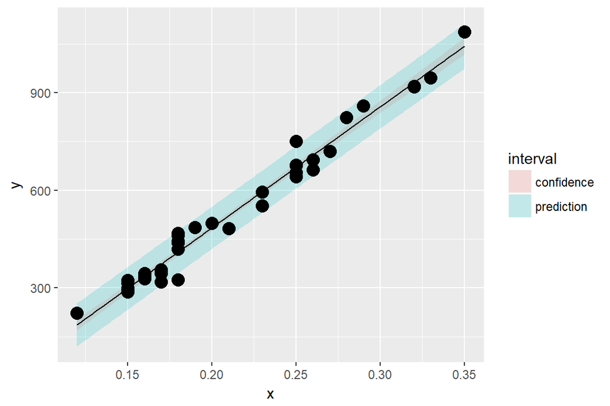

```r
# create a sequence of values that we want to predict at
newx = data.frame(x = seq(min(x), max(x), length = 100))
# calculate values for both intervals
p1 = data.frame(predict(fit, newdata = newx, interval = ("confidence")))
p2 = data.frame(predict(fit, newdata = newx, interval = ("prediction")))
# add column for interval labels
p1$interval = "confidence"; p2$interval = "prediction"
# add column for the x values we want to predict
p1$x = newx$x; p2$x = newx$x
# combine the two dataframes
dat = rbind(p1, p2)
# change the name of the first column to y
names(dat)[1] = "y"
# plot the data
g <- ggplot(dat, aes(x = x, y = y))
g <- g + geom_ribbon(aes(ymin = lwr, ymax = upr, fill = interval), alpha = 0.2)
g <- g + geom_line()
g + geom_point(data = data.frame(x = x, y=y), aes(x = x, y = y), size = 4)
```

- *Example (`base`)*

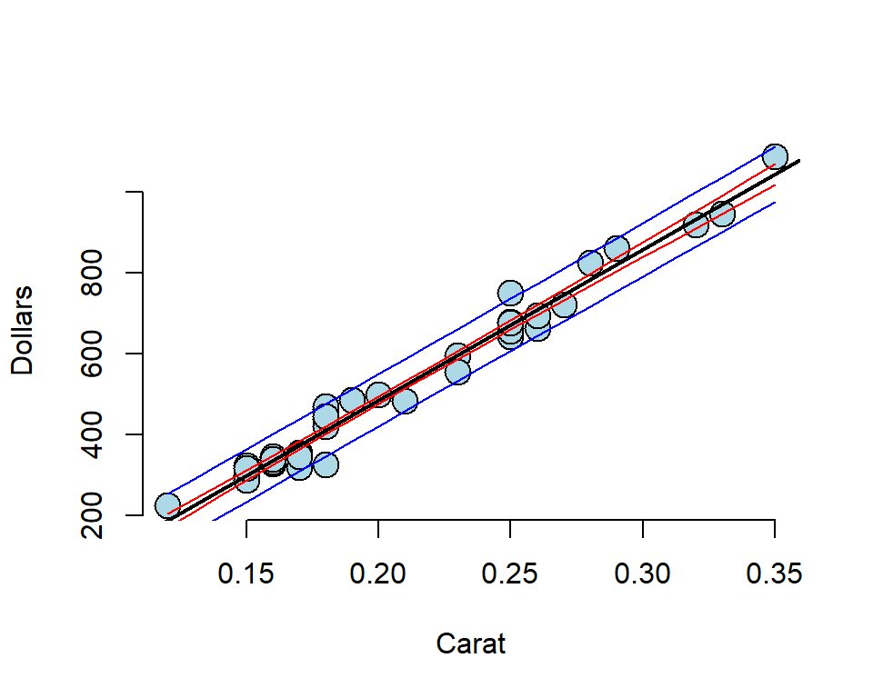

```r
# plot the x and y values
plot(x,y,frame=FALSE,xlab="Carat",ylab="Dollars",pch=21,col="black",bg="lightblue",cex=2)
# add the fit line
abline(fit,lwd=2)
# create sequence of x values that we want to predict at
xVals<-seq(min(x),max(x),by=.01)
# calculate the predicted y values
yVals<-beta0+beta1*xVals
# calculate the standard errors for the interval for the line
se1<-sigma*sqrt(1/n+(xVals-mean(x))^2/ssx)
# calculate the standard errors for the interval for the predicted values
se2<-sigma*sqrt(1+1/n+(xVals-mean(x))^2/ssx)
# plot the upper and lower bounds of both intervals
lines(xVals,yVals+2*se1, col = "red"); lines(xVals,yVals-2*se1, col = "red")
lines(xVals,yVals+2*se2, col = "blue"); lines(xVals,yVals-2*se2, col = "blue")
```

- Both intervals have varying widths.
  - Least width at the mean of the Xs.
- We are quite confident in the regression line, so that interval is very narrow.
  - If we knew $\beta_0$ and $\beta_1$ this interval would have zero width.
- The prediction interval must incorporate the variabilibity in the data around the line.
  - Even if we knew $\beta_0$ and $\beta_1$ this interval would still have width.

# 10 Multivariate Regression

- **Intro**: We now extend linear regression so that our models can contain more variables. A natural first approach is to assume additive effects, basically extending our line to a plane, or generalized version of a plane as we add more variables. Multivariable regression represents one of the most widely used and successful methods in statistics.
- linear models are the single most important applied statistical and machine learning technique
- Some amazing things that you can accomplish with linear models
  - Decompose a signal into its harmonics.
  - Flexibly fit complicated functions.
  - Fit factor variables as predictors.
  - Uncover complex multivariate relationships with the response.
  - Build accurate prediction models.
- **generalized linear model** extends simple linear regression (SLR) model
  $$Y_i = \beta_1 X_{1i} + \beta_2 X_{2i} + \ldots +\beta_{p} X_{pi} + \epsilon_{i} = \sum_{k=1}^p X_{ik} \beta_j + \epsilon_{i}$$
  where $X_{1i}=1$ typically, so that an intercept is included
- least squares/MLE for the model (under iid Gaussian errors) minimizes
  $$\sum_{i=1}^n \left(Y_i - \sum_{k=1}^p X_{ki} \beta_j\right)^2$$
- **linearity of coefficients** is what defines a linear model as transformations of the variables (i.e. squaring) still yields a linear model
  $$Y_i = \beta_1 X_{1i}^2 + \beta_2 X_{2i}^2 + \ldots +\beta_{p} X_{pi}^2 + \epsilon_{i}$$
- performing multivariate regression = pick any regressor and replace the outcome and all other regressors by their residuals against the chosen one

## 10.1 Derivation of Coefficients

- we know for simple univariate regression through the origin
  $$E[Y_i]=X_{1i}\beta_1 \\ \hat \beta_1 = \frac{\sum_{i=1}^n X_i Y_i}{\sum_{i=1}^n X_i^2}$$
- we want to minimize
  $$\sum_{i=1}^n (Y_i - X_{1i}\beta_1 - X_{2i}\beta_2 - \ldots - X_{pi}\beta_p)^2$$
- we begin by looking at the two variable model where
  $$E[Y_i] = \mu_i = X_{1i}\beta_1 + X_{2i}\beta_2 \\ \hat \mu_i = X_{1i}\hat \beta_1 + X_{2i}\hat \beta_2$$
- from our previous derivations, to minimize the sum of squares, the following has to true
  $$\sum_{i=1}^n (Y_i - \hat \mu_i) (\hat \mu_i - \mu_i) = 0$$
- plugging in $\hat \mu_i$ and $\mu_i$
  $$\begin{aligned}
  \sum_{i=1}^n (Y_i - \hat \mu_i) (\hat \mu_i - \mu_i) & = \sum_{i=1}^n (Y_i - X_{1i}\hat \beta_1 - X_{2i}\hat \beta_2)(X_{1i}\hat \beta_1 + X_{2i}\hat \beta_2 - X_{1i}\beta_1 - X_{2i}\beta_2)\\
  (simplifying) & = \sum_{i=1}^n (Y_i - X_{1i}\hat \beta_1 - X_{2i}\hat \beta_2)\left[ X_{1i}(\hat \beta_1 - \beta_1) + X_{2i} (\hat \beta_2 - \beta_2)\right]\\
  (expanding) & = \sum_{i=1}^n (Y_i - X_{1i}\hat \beta_1 - X_{2i}\hat \beta_2) X_{1i}(\hat \beta_1 - \beta_1) + \sum_{i=1}^n (Y_i - X_{1i}\hat \beta_1 - X_{2i}\hat \beta_2) X_{2i} (\hat \beta_2 - \beta_2)\\
  \end{aligned}$$
- for the entire expression to equal to zero,
  $$\begin{aligned}
  \sum_{i=1}^n (Y_i - X_{1i}\hat \beta_1 - X_{2i}\hat \beta_2) X_{1i}(\hat \beta_1 - \beta_1) & = 0 \\
  (since~\hat \beta_1,~\beta_1~don't~depend~on~i) \Rightarrow \sum_{i=1}^n (Y_i - X_{1i}\hat \beta_1 - X_{2i}\hat \beta_2) X_{1i}& = 0 ~ ~ ~ ~ ~ ~\mbox{(1)}\\
  \\
  \sum_{i=1}^n (Y_i - X_{1i}\hat \beta_1 - X_{2i}\hat \beta_2) X_{2i}(\hat \beta_2 - \beta_2) & = 0 \\
  (since~\hat \beta_2,~\beta_2~don't~depend~on~i) \Rightarrow \sum_{i=1}^n (Y_i - X_{1i}\hat \beta_1 - X_{2i}\hat \beta_2) X_{2i} & = 0 ~ ~ ~ ~ ~ ~\mbox{(2)}\\
  \end{aligned}$$
- we can hold $\hat \beta_1$ fixed and solve **(2)** for $\hat \beta_2$
  $$\begin{aligned}
  \sum_{i=1}^n (Y_i - X_{1i}\hat \beta_1) X_{2i} - \sum_{i=1}^n X_{2i}^2 \hat \beta_2& = 0\\
  \sum_{i=1}^n (Y_i - X_{1i}\hat \beta_1) X_{2i} &= \sum_{i=1}^n X_{2i}^2 \hat \beta_2 \\
  \hat \beta_2 & = \frac{\sum_{i=1}^n (Y_i - X_{1i}\hat \beta_1) X_{2i}}{\sum_{i=1}^n X_{2i}^2} \\
  \end{aligned}$$
- plugging $\hat \beta_2$ back into **(1)**, we get
  $$\begin{aligned}
  \sum_{i=1}^n \left[Y_i - X_{1i}\hat \beta_1 - \frac{\sum_{j=1}^n (Y_j - X_{1j}\hat \beta_1) X_{2j}}{\sum_{j=1}^n X_{2j}^2}X_{2i}\right] X_{1i} & = 0 \\
  \sum_{i=1}^n \left[Y_i - X_{1i}\hat \beta_1 - \frac{\sum_{j=1}^n Y_jX_{2j}}{\sum_{j=1}^n X_{2j}^2}X_{2i} + \frac{\sum_{j=1}^n X_{1j} X_{2j}}{\sum_{j=1}^n X_{2j}^2}X_{2i}\hat \beta_1\right] X_{1i} & = 0 \\
  \sum_{i=1}^n \left[\left(Y_i - \frac{\sum_{j=1}^n Y_jX_{2j}}{\sum_{j=1}^n X_{2j}^2}X_{2i}\right) - \hat \beta_1 \left(X_{1i} - \frac{\sum_{j=1}^n X_{1j} X_{2j}}{\sum_{j=1}^n X_{2j}^2}X_{2i}\right)\right] X_{1i} & = 0 \\
  \Rightarrow \left(Y_i - \frac{\sum_{j=1}^n Y_jX_{2j}}{\sum_{j=1}^n X_{2j}^2}X_{2i}\right) & = \mbox{residual for } Y_i = X_{i2} \hat \beta_2 + \epsilon_i\\
  \Rightarrow \left(X_{1i} - \frac{\sum_{j=1}^n X_{1j} X_{2j}}{\sum_{j=1}^n X_{2j}^2}X_{2i}\right) & = \mbox{residual for } X_{i1} = X_{i2} \hat \gamma + \epsilon_i\\
  \end{aligned}$$
- we can rewrite
  $$\sum_{i=1}^n \left[\left(Y_i - \frac{\sum_{j=1}^n Y_jX_{2j}}{\sum_{j=1}^n X_{2j}^2}X_{2i}\right) - \hat \beta_1 \left(X_{1i} - \frac{\sum_{j=1}^n X_{1j} X_{2j}}{\sum_{j=1}^n X_{2j}^2}X_{2i}\right)\right] X_{1i} = 0 ~ ~ ~ ~ ~ ~(3)$$
  as
  $$\sum_{i=1}^n \left[ e_{i, Y|X_2} -\hat \beta_1 e_{i, X_1|X_2} \right] X_{1i}= 0$$
  where
  $$e_{i, a|b} = a_i - \frac{ \sum_{j=1}^n a_j b_j}{ \sum_{j=1}^n b_j^2}b_i$$
  which is interpreted as the residual when regressing $b$ from $a$ without an intercept
- We get the solution
  $$\hat \beta_1 = \frac{\sum_{i=1}^n e_{i, Y | X_2} e_{i, X_1 | X_2}}{\sum_{i=1}^n e_{i, X_1 | X_2}X_{1i}} ~ ~ ~ ~ ~ ~(4)$$
- But note that
  $$\begin{aligned}
  \sum_{i=1}^n e_{i, X_1 | X_2}^2 & = \sum_{i=1}^n e_{i, X_1 | X_2}\left(X_{1i} - \frac{\sum_{j=1}^n X_{1j}X_{2j} }{ \sum_{j=1}^n X_{2j}^2 } X_{2i}\right) \\
  & = \sum_{i=1}^n e_{i, X_1 | X_2}X_{1i} - \frac{\sum_{j=1}^n X_{1j}X_{2j} }{ \sum_{j=1}^n X_{2j}^2 } \sum_{i=1}^n e_{i, X_1 | X_2} X_{2i}\\
  & (recall~that~ \sum_{i=1}^n e_{i}X_i = 0,~so~the~2^{nd}~term~is~0) \\
  \Rightarrow \sum_{i=1}^n e_{i, X_1 | X_2}^2 & = \sum_{i=1}^n e_{i, X_1 | X_2}X_{1i}\\
  \end{aligned}$$
- plugging the above equation back into **(4)**, we get
  $$\hat \beta_1 = \frac{\sum_{i=1}^n e_{i, Y | X_2} e_{i, X_1 | X_2}}{\sum_{i=1}^n e_{i, X_1 | X_2}^2}$$
- **general case**
  - pick one regressor and to replace all other variables by the residuals of their regressions against that one
    $$\sum_{i=1}^n (Y_i - X_{1i}\hat \beta_1 - \ldots - X_{pi}\hat \beta_p)X_k = 0$$
    for $k = 1, \ldots, p$ yields $p$ equations with $p$ unknowns
  - holding $\hat \beta_1, \ldots, \hat \beta_{p-1}$ constant, we get
    $$\hat \beta_p = \frac{ \sum_{i=1}^n (Y_i - X_{1i}\hat \beta_1 - \ldots - X_{p-1, i}\hat \beta_{p-1})X_{pi}}{\sum_{i=1}^n X_{pi}^2}$$
  - plugging $\hat \beta_p$ back into the equation
    $$\sum_{i=1}^n (e_{i,Y|X_p} - e_{i,X_1|X_p}\hat \beta_1 - \ldots - e_{i,X_{p-1}|X_p}\hat \beta_{p-1} )X_k = 0$$
  - Note that
    $$X_k = e_{i,X_k|X_p} + \frac{\sum_{i=1}^n X_{ki}X_{pi}}{\sum_{i=1}^n X_{pi}^2}X_p$$
    and that
    $$\sum_{i=1}^n e_{i,X_j|X_p}X_{pi} = 0$$
    Thus
    $$\sum_{i=1}^n (e_{i,Y|X_p} - e_{i,X_1|X_p}\hat \beta_1 - \ldots - e_{i,X_{p-1}|X_p}\hat \beta_{p-1} )X_k = 0$$
    is equal to
    $$\sum_{i=1}^n (e_{i,Y|X_p} - e_{i,X_1|X_p}\hat \beta_1 - \ldots - e_{i,X_{p-1}|X_p}\hat \beta_{p-1} )e_{i, X_k|X_p} = 0$$
  - this procedure reduces $p$ LS equations and p unknowns to $p-1$ LS equations and $p-1$ unknowns
    - every variable is replaced by its residual with $X_p$
    - process iterates until **only $Y$** and **one variable remains**
    - or more intuitively, we take residuals over the confounding variables and do regression through the origin
- *Example*
  - for simple linear regression, $Y_{i} = \beta_1 X_{1i} + \beta_2 X_{2i}$ where $X_{2i} = 1$ is an intercept term
  - the residuals
    $$e_{i, Y | X_2} = Y_i - \frac{ \sum_{j=1}^n Y_j X_{2j}}{ \sum_{j=1}^n X_{2j}^2}X_{2i} = Y_i - \bar Y$$
    - **Note**: this is according to previous derivation of the slope of a regression line through the origin
  - the residuals $e_{i, X_1 | X_2}= X_{1i} - \frac{\sum_{j=1}^n X_{1j}X_{2j}}{\sum_{j=1}^n X_{2j}^2}X_{2i} = X_{1i} - \bar X_1$
    - **Note**: this is according to previous derivation of the slope of a regression line through the origin
  - Thus
    $$\hat \beta_1 = \frac{\sum_{i=1}^n e_{i, Y | X_2} e_{i, X_1 | X_2}}{\sum_{i=1}^n e_{i, X_1 | X_2}^2} = \frac{\sum_{i=1}^n (X_i - \bar X)(Y_i - \bar Y)}{\sum_{i=1}^n (X_i - \bar X)^2} = Cor(X, Y) \frac{Sd(Y)}{Sd(X)}$$

## 10.2 Interpretation of Coefficients

- from the derivation in the previous section, we have
  $$\hat \beta_1 = \frac{\sum_{i=1}^n e_{i, Y | X_2} e_{i, X_1 | X_2}}{\sum_{i=1}^n e_{i, X_1 | X_2}^2}$$
- this is interpreted as the effect of variable $X_1$ when the effects of all other variables have been removed from $X_1$ and the predicted result $Y$ (holding everything else constant/adjusting for all other variables)
- the expected response is as follows
  $$E[Y | X_1 = x_1, \ldots, X_p = x_p] = \sum_{k=1}^p x_{k} \beta_k$$
  so the expected change in the response through change in one variable is
  $$\begin{aligned}
  & E[Y | X_1 = x_1 + 1, \ldots, X_p = x_p] - E[Y | X_1 = x_1, \ldots, X_p = x_p] \\
  = & (x_1 + 1) \beta_1 + \sum_{k=2}^p x_{k} \beta_k - \sum_{k=1}^p x_{k} \beta_k \\
  = & (x_1 + 1) \beta_1 + \sum_{k=2}^p x_{k} \beta_k - (x_1 \beta_1 + \sum_{k=2}^p x_{k} \beta_k) \\
  = & \beta_1 \\
  \end{aligned}$$
- therefore, interpretation of a multivariate regression coefficient $\rightarrow$ expected change in the response per unit change in the regressor, holding all of the other regressors fixed
- all of the SLR properties/calculations extend to generalized linear model
  - *model* = $Y_i = \sum_{k=1}^p X_{ik} \beta_{k} + \epsilon_{i}$ where $\epsilon_i \sim N(0, \sigma^2)$
  - *fitted response* = $\hat Y_i = \sum_{k=1}^p X_{ik} \hat \beta_{k}$
  - *residual* = $e_i = Y_i - \hat Y_i$
  - *variance estimate* = $\hat \sigma^2 = \frac{1}{n-p} \sum_{i=1}^n e_i ^2$
  - *predicted responses at new values, $x_1, \ldots, x_p$* = plug $x$ values into $\sum_{k=1}^p x_{k} \hat \beta_{k}$
  - *standard errors of coefficients* = $\hat \sigma_{\hat \beta_k}$
  - *test/CI statistic* = $\frac{\hat \beta_k - \beta_k}{\hat \sigma_{\hat \beta_k}}$ follows a $T$ distribution with $n-p$ degrees of freedom
  - *predicted/expected response intervals* = calculated using standard errors of predicted responses of $\hat Y_i$

## 10.3 Example: Linear Model with 2 Variables and Intercept

```r
# simulate the data
n = 100; x = rnorm(n); x2 = rnorm(n); x3 = rnorm(n)
# equation = intercept + var1 + var2 + var3 + error
y = 1 + x + x2 + x3 + rnorm(n, sd = .1)
# residual of y regressed on var2 and var3
ey = resid(lm(y ~ x2 + x3))
# residual of y regressed on var2 and var3
ex = resid(lm(x ~ x2 + x3))
# estimate beta1 for var1
sum(ey * ex) / sum(ex ^ 2)
```

```
## [1] 0.9978401
```

```r
# regression through the origin with xva1 with var2 var3 effect removed
coef(lm(ey ~ ex - 1))
```

```
##        ex
## 0.9978401
```

```r
# regression for all three variables
coef(lm(y ~ x + x2 + x3))
```

```
## (Intercept)           x          x2          x3
##   0.9922332   0.9978401   1.0097214   1.0050856
```

## 10.4 Example: Coefficients that Reverse Signs

- **Note**: more information can be found at `?swiss`
- data set is composed of standardized fertility measure and socio-economic indicators for each of 47 French-speaking provinces of Switzerland at about 1888
- data frame has 47 observations on 6 variables, each of which is in percent [0, 100]
  - *Fertility* = common standardized fertility measure $\rightarrow$ outcome
  - *Agriculture* = % of males involved in agriculture as occupation
  - *Examination* = % draftees receiving highest mark on army examination
  - *Education* = % education beyond primary school for draftees
  - *Catholic* = % catholic vs protestant
  - *Infant.Mortality* = live births who live less than 1 year
- [`GGally` package] `ggpairs(data)` = produces pair wise plot for the predictors similar to `pairs` in base package

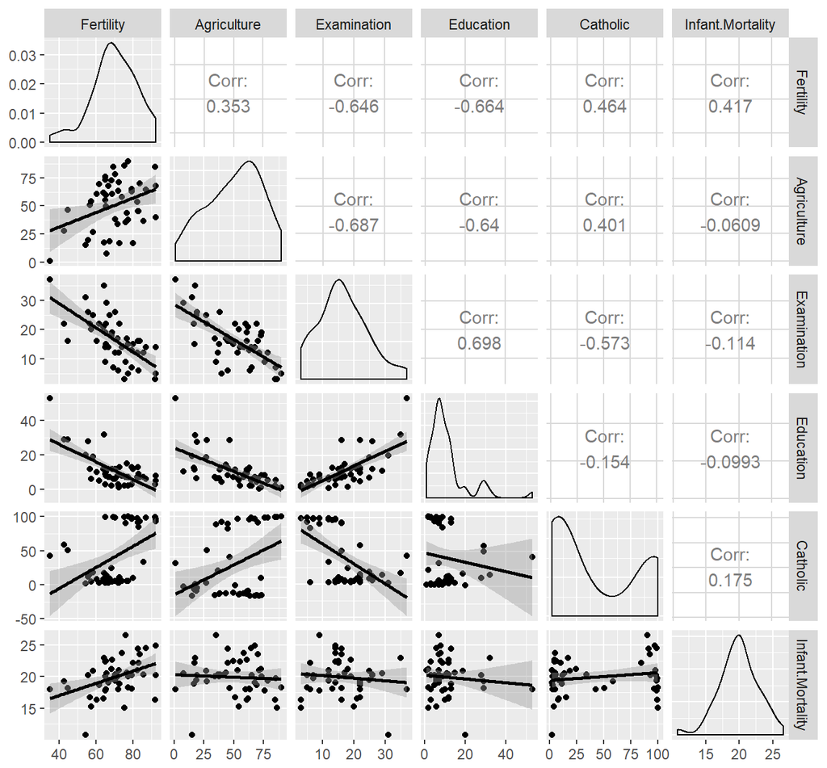

```r
# load dataset
require(datasets); data(swiss); require(GGally)

# produce pairwise plot using ggplot2
ggpairs(swiss, lower = list(continuous = wrap("smooth", method = "lm")))
```

```r
# print coefficients of regression of fertility on all predictors
summary(lm(Fertility ~ . , data = swiss))$coefficients
```

```
##                    Estimate  Std. Error   t value     Pr(>|t|)
## (Intercept)      66.9151817 10.70603759  6.250229 1.906051e-07
## Agriculture      -0.1721140  0.07030392 -2.448142 1.872715e-02
## Examination      -0.2580082  0.25387820 -1.016268 3.154617e-01
## Education        -0.8709401  0.18302860 -4.758492 2.430605e-05
## Catholic          0.1041153  0.03525785  2.952969 5.190079e-03
## Infant.Mortality  1.0770481  0.38171965  2.821568 7.335715e-03
```

- interpretation for Agriculture coefficient
  - we expect an -0.17 **decrease** in standardized *fertility* for every 1% increase in percentage of *males involved in agriculture* in holding the remaining variables constant
  - since the p-value is 0.0187272, the t-test for $H_0: \beta_{Agri} = 0$ versus $H_a: \beta_{Agri} \neq 0$ is *significant*
- however, if we look at the unadjusted estimate (marginal regression) for the coefficient for Agriculture

```r
# run marginal regression on Agriculture
summary(lm(Fertility ~ Agriculture, data = swiss))$coefficients
```

```
##               Estimate Std. Error   t value     Pr(>|t|)
## (Intercept) 60.3043752 4.25125562 14.185074 3.216304e-18
## Agriculture  0.1942017 0.07671176  2.531577 1.491720e-02
```

- interpretation for Agriculture coefficient
  - we expect an 0.19 **increase** in standardized *fertility* for every 1% increase in percentage of *males involved in agriculture* in holding the remaining variables constant
    - **Note**: the coefficient **flipped signs**
  - since the p-value is 0.0149172, the t-test for $H_0: \beta_{Agri} = 0$ versus $H_a: \beta_{Agri} \neq 0$ is *significant*
- to see intuitively how a **sign change** is possible, we can look at the following simulated example

```r
# simulate data
n <- 100; x2 <- 1 : n; x1 <- .01 * x2 + runif(n, -.1, .1); y = -x1 + x2 + rnorm(n, sd = .01)
# print coefficients
c("with x1" = summary(lm(y ~ x1))$coef[2,1],
    "with x1 and x2" = summary(lm(y ~ x1 + x2))$coef[2,1])
```

```
##        with x1 with x1 and x2
##     93.9557139     -0.9980595
```

```r
# print p-values
c("with x1" = summary(lm(y ~ x1))$coef[2,4],
    "with x1 and x2" = summary(lm(y ~ x1 + x2))$coef[2,4])
```

```
##        with x1 with x1 and x2
##   2.111823e-68   9.819490e-80
```

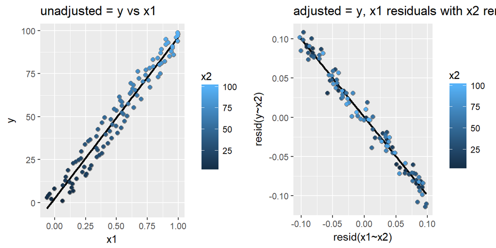

```r
# store all data in one data frame (ey and ex1 are residuals with respect to x2)
dat <- data.frame(y = y, x1 = x1, x2 = x2, ey = resid(lm(y ~ x2)), ex1 = resid(lm(x1 ~ x2)))
# plot y vs x1
g <- ggplot(dat, aes(y = y, x = x1, colour = x2)) +
    geom_point(colour="grey50", size = 2) +
    geom_smooth(method = lm, se = FALSE, colour = "black") + geom_point(size = 1.5) +
    ggtitle("unadjusted = y vs x1")
# plot residual of y adjusted for x2 vs residual of x1 adjusted for x2
g2 <- ggplot(dat, aes(y = ey, x = ex1, colour = x2)) +
    geom_point(colour="grey50", size = 2) +
    geom_smooth(method = lm, se = FALSE, colour = "black") + geom_point(size = 1.5) +
    ggtitle("adjusted = y, x1 residuals with x2 removed") + labs(x = "resid(x1~x2)",
        y = "resid(y~x2)")
# combine plots
multiplot(g, g2, cols = 2)
```

- as we can see from above, the correlation between `y` and `x1` flips signs when adjusting for `x2`
- this effectively means that within each consecutive group/subset of points (each color gradient) on the left hand plot (unadjusted), there exists a negative relationship between the points while the overall trend is going up
- *going back to the swiss data set*, the sign of the coefficient for Agriculture *reverses* itself with the inclusion of Examination and Education (both are *negatively correlated* with Agriculture)
  - correlation between Agriculture and Education: -0.64
  - correlation between Agriculture and Examination: -0.69
  - correlation between Education and Examination: 0.7
    - this means that the two variables are likely to be measuring the same things
- **Note**: it is **difficult to interpret** and determine which one is the correct model $\rightarrow$ one **should not** claim positive correlation between Agriculture and Fertility simply based on marginal regression `lm(Fertility ~ Agriculture, data=swiss)`

## 10.5 Example: Unnecessary Variables

- **unnecessary predictors** = variables that don’t provide any new linear information, meaning that the variable are simply *linear combinations* (multiples, sums) of other predictors/variables
- when running a linear regression with unnecessary variables, R automatically drops the linear combinations and returns `NA` as their coefficients

```r
# add a linear combination of agriculture and education variables
z <- swiss$Agriculture + swiss$Education
# run linear regression with unnecessary variables
lm(Fertility ~ . + z, data = swiss)$coef
```

```
##      (Intercept)      Agriculture      Examination        Education
##       66.9151817       -0.1721140       -0.2580082       -0.8709401
##         Catholic Infant.Mortality                z
##        0.1041153        1.0770481               NA
```

- as we can see above, the R dropped the unnecessary variable `z` by excluding it from the linear regression $\rightarrow$ `z`’s coefficient is `NA`

# 11 Dummy Variables

- **dummy variables** = binary variables that take on value of **1** when the measurement is in a particular group, and **0** when the measurement is not (i.e. in clinical trials, treated = 1, untreated = 0)
- in linear model form,
  $$Y_i = \beta_0 + X_{i1} \beta_1 + \epsilon_{i}$$
  where $X_{i1}$ is a binary/dummy variable so that it is a 1 if measurement $i$ is in a group and 0 otherwise
  - for people in the group, the mean or $\mu_{X_{i1} = 1} = E[Y_i] = \beta_0 + \beta_1$
  - for people *not* in the group, the mean or $\mu_{X_{i1} = 0} = E[Y_i] = \beta_0$
  - predicted mean for group = $\hat \beta_0 + \hat \beta_1$
  - predicted mean for not in group = $\hat \beta_0$
  - coefficient $\beta_1$ for $X_{i1}$ is interpreted as the *increase or decrease* in the **mean** when comparing two groups (in vs not)
  - **Note**: including a dummy variable that is 1 for not in the group would be **redundant** as it would simply be a linear combination $1 - X_{i1}$

## 11.1 More Than 2 Levels

- for 3 factor levels, we would need 2 dummy variables and the model would be
  $$Y_i = \beta_0 + X_{i1} \beta_1 + X_{i2} \beta_2 + \epsilon_i$$
- for this example, we will use the above model to analyze US political party affiliations (Democrats vs Republicans vs independents) and denote the variables as follows:
  - $X_{i1} = 1$ for Republicans and $0$ otherwise
  - $X_{i2} = 1$ for Democrats and $0$ otherwise
  - If $i$ is Republican, $X_{i1} = 1$, $X_{i2} = 0$, $E[Y_i] = \beta_0 +\beta_1$
  - If $i$ is Democrat, $X_{i1} = 0$, $X_{i2} = 1$, $E[Y_i] = \beta_0 + \beta_2$
  - If $i$ is independent, $X_{i1} = 0$, $X_{i2} = 0$, $E[Y_i] = \beta_0$
  - $\beta_1$ compares Republicans to independents
  - $\beta_2$ compares Democrats to independents
  - $\beta_1 - \beta_2$ compares Republicans to Democrats
- **Note**: choice of reference category (independent in this case) changes the interpretation
  - **reference category** = the group whose binary variable has been eliminated
- the same principles explained above can be expanded to $p$ level model
  $$Y_i = \beta_0 + X_{i1} \beta_1 + X_{i2} \beta_2 + \ldots + X_{ip} \beta_p + \epsilon_i$$

## 11.2 Example: 6 Factor Level Insect Spray Data

- below is a violin plot of the 6 different types (A, B, C, D, E, and F) of insect sprays and their potency (kill count) from `InsectSprays` data set
  - **Note**: the varying width of each bar indicates the density of measurement at each value

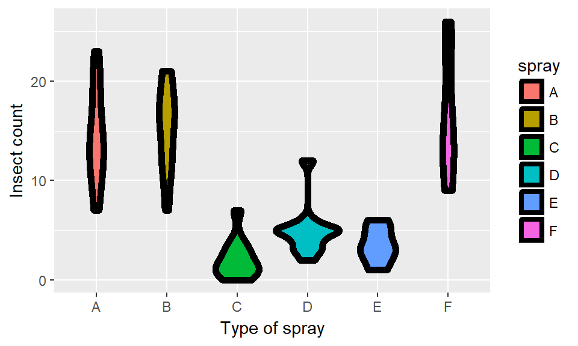

```r
# load insect spray data
data(InsectSprays)
ggplot(data = InsectSprays, aes(y = count, x = spray, fill  = spray)) +
    geom_violin(colour = "black", size = 2) + xlab("Type of spray") +
    ylab("Insect count")
```

**Linear model fit with group A as reference category**

```r
# linear fit with 5 dummy variables
fit <- summary(lm(count ~ spray, data = InsectSprays))$coefficients; fit
```

```
##                Estimate Std. Error    t value     Pr(>|t|)
## (Intercept)  14.5000000   1.132156 12.8074279 1.470512e-19
## sprayB        0.8333333   1.601110  0.5204724 6.044761e-01
## sprayC      -12.4166667   1.601110 -7.7550382 7.266893e-11
## sprayD       -9.5833333   1.601110 -5.9854322 9.816910e-08
## sprayE      -11.0000000   1.601110 -6.8702352 2.753922e-09
## sprayF        2.1666667   1.601110  1.3532281 1.805998e-01
```

- **Note**: R automatically converts factor variables into $n-1$ dummy variables and uses the first category as reference
  - mean of group A is therefore the default intercept
- the above coefficients can be interpreted as the difference in means between each group (B, C, D, E, and F) and group A (the intercept)
  - example: the mean of group B is 0.83 higher than the mean of group A, which is 14.5
  - means for group B/C/D/E/F = the intercept + their respective coefficient
  - 0.83 minus -12.42 compares group B with group C
- all t-tests are for comparisons of Sprays versus Spray A

**Hard-coding the dummy variables**

- this produces the exact same result as the command `lm(count ~ spray, data = InsectSprays)`

```r
# hard coding dummy variables
summary(lm(count ~ I(1 * (spray == 'B')) + I(1 * (spray == 'C')) +
           I(1 * (spray == 'D')) + I(1 * (spray == 'E')) +
           I(1 * (spray == 'F')), data = InsectSprays))$coefficients
```

```
##                          Estimate Std. Error    t value     Pr(>|t|)
## (Intercept)            14.5000000   1.132156 12.8074279 1.470512e-19
## I(1 * (spray == "B"))   0.8333333   1.601110  0.5204724 6.044761e-01
## I(1 * (spray == "C")) -12.4166667   1.601110 -7.7550382 7.266893e-11
## I(1 * (spray == "D"))  -9.5833333   1.601110 -5.9854322 9.816910e-08
## I(1 * (spray == "E")) -11.0000000   1.601110 -6.8702352 2.753922e-09
## I(1 * (spray == "F"))   2.1666667   1.601110  1.3532281 1.805998e-01
```

**Linear model fit with all 6 categories**

```r
# linear fit with 6 dummy variables
lm(count ~ I(1 * (spray == 'B')) + I(1 * (spray == 'C')) +
           I(1 * (spray == 'D')) + I(1 * (spray == 'E')) +
           I(1 * (spray == 'F')) + I(1 * (spray == 'A')),
           data = InsectSprays)$coefficients
```

```
##           (Intercept) I(1 * (spray == "B")) I(1 * (spray == "C"))
##            14.5000000             0.8333333           -12.4166667
## I(1 * (spray == "D")) I(1 * (spray == "E")) I(1 * (spray == "F"))
##            -9.5833333           -11.0000000             2.1666667
## I(1 * (spray == "A"))
##                    NA
```

- as we can see from above, the coefficient for group `A` is `NA`
- this is because $X_{iA} = 1 - X_{iB} - X_{iC}- X_{iD}- X_{iE}- X_{iF}$, or the dummy variable for A is a linear combination of the rest of the dummy variables

**Linear model fit with omitted intercept**

- eliminating the intercept would mean that each group is compared to the value 0, which would yield 6 variables since A is no longer the reference category
- this means that the coefficients for the 6 variables are simply the *mean* of each group
  - when $X_{iA} = 1$, all the other dummy variables become 0, which means the linear model becomes
    $$Y_i = \beta_A + \epsilon_i$$
  - then $E[Y_i] = \beta_A = \mu_A$
  - this makes sense because the *best prediction* for the kill count of spray of type A is the *mean* of recorded kill counts of A spray

```r
# linear model with omitted intercept
nfit <- summary(lm(count ~ spray - 1, data = InsectSprays))$coefficients; nfit
```

```
##         Estimate Std. Error   t value     Pr(>|t|)
## sprayA 14.500000   1.132156 12.807428 1.470512e-19
## sprayB 15.333333   1.132156 13.543487 1.001994e-20
## sprayC  2.083333   1.132156  1.840148 7.024334e-02
## sprayD  4.916667   1.132156  4.342749 4.953047e-05
## sprayE  3.500000   1.132156  3.091448 2.916794e-03
## sprayF 16.666667   1.132156 14.721181 1.573471e-22
```

```r
# actual means of count by each variable
round(tapply(InsectSprays$count, InsectSprays$spray, mean), 2)
```

```
##     A     B     C     D     E     F
## 14.50 15.33  2.08  4.92  3.50 16.67
```

- p-values are testing for whether the groups are different from zero (i.e. are the expected counts 0 for that spray?)
  - compared to the model above, where groups are compared to group A, the p-values tests whether or not A is different from B, A is different from C, etc. $\rightarrow$ want one of the groups to be a reference level, because then can do some tests
- to compare between different categories, say B vs C, we can simply subtract the coefficients

**Reordering the levels**

- to reorient the model with other groups as reference categories, we can simply **reorder the levels** for the factor variable
  - `relevel(var, "l")` = reorders the factor levels within the factor variable `var` such that the specified level “l” is the reference/base/lowest level
    - **Note**: R automatically uses the first/base level as the reference category during a linear regression

```r
# reorder the levels of spray variable such that C is the lowest level
spray2 <- relevel(InsectSprays$spray, "C")
# rerun linear regression with releveled factor
fit2 <- summary(lm(count ~ spray2, data = InsectSprays))$coef; fit2
```

```
##              Estimate Std. Error  t value     Pr(>|t|)
## (Intercept)  2.083333   1.132156 1.840148 7.024334e-02
## spray2A     12.416667   1.601110 7.755038 7.266893e-11
## spray2B     13.250000   1.601110 8.275511 8.509776e-12
## spray2D      2.833333   1.601110 1.769606 8.141205e-02
## spray2E      1.416667   1.601110 0.884803 3.794750e-01
## spray2F     14.583333   1.601110 9.108266 2.794343e-13
```

- it is important to note in this example that
  - counts are bounded from below by 0 $\rightarrow$ *violates* the assumption of normality of the errors
  - there are counts near zero $\rightarrow$ *violates* intent of the assumption $\rightarrow$ not acceptable in assuming normal distribution
  - variance does not appear to be constant across different type of groups (see: violin plot) $\rightarrow$ violates assumption
    - taking log(counts + 1) may help (+1 since there are zero counts)
  - *Poisson GLMs* are better (don’t have to worry about the assumptions) for fitting count data

**Calculating t-statistics manually**

- calculating the spray2B t value

```r
#(fit[2,1]-fit[3,1])/1.60111
fit2[3,1]/fit2[3,2]
```

```
## [1] 8.275511
```

# 12 Interactions

- **interactions** between variables can be added to a regression model to test how the outcomes change under different conditions
- we will use the data set from the Millennium Development Goal from the UN which can be found [here](https://github.com/bcaffo/courses/blob/master/07_RegressionModels/02_02_multivariateExamples/hunger.csv)
  - `Numeric` = values for children aged <5 years underweight (%)
  - `Sex` = records whether
  - `Year` = year when data was recorded
  - `Income` = income for the child’s parents

```r
# load in hunger data
hunger <- read.csv("./data/hunger.csv")
# exclude the data with "Both Sexes" as values (only want Male vs Female)
hunger <- hunger[hunger$Sex!="Both sexes", ]
# structure of data
str(hunger)
```

```
## 'data.frame':    948 obs. of  12 variables:
##  $ Indicator     : Factor w/ 1 level "Children aged <5 years underweight (%)": 1 1 1 1 1 1 1 1 1 1 ...
##  $ Data.Source   : Factor w/ 670 levels "NLIS_310005",..: 7 52 519 380 548 551 396 503 643 632 ...
##  $ PUBLISH.STATES: Factor w/ 1 level "Published": 1 1 1 1 1 1 1 1 1 1 ...
##  $ Year          : int  1986 1990 2005 2002 2008 2008 2003 2006 2012 1999 ...
##  $ WHO.region    : Factor w/ 6 levels "Africa","Americas",..: 1 2 2 3 1 1 1 2 1 2 ...
##  $ Country       : Factor w/ 151 levels "Afghanistan",..: 115 104 97 69 57 54 71 13 115 144 ...
##  $ Sex           : Factor w/ 3 levels "Both sexes","Female",..: 3 3 3 2 2 3 3 3 3 2 ...
##  $ Display.Value : num  19.3 2.2 5.3 3.2 17 15.7 19.3 4 15.5 4.2 ...
##  $ Numeric       : num  19.3 2.2 5.3 3.2 17 15.7 19.3 4 15.5 4.2 ...
##  $ Low           : logi  NA NA NA NA NA NA ...
##  $ High          : logi  NA NA NA NA NA NA ...
##  $ Comments      : logi  NA NA NA NA NA NA ...
```

## 12.1 Model: % Hungry ~ Year by Sex

- this will include 2 models with 2 separate lines
- model for % hungry ($H_F$) vs year ($Y_F$) for females is
  $$H_{Fi} = \beta_{F0} + \beta_{F1} Y_{Fi} + \epsilon_{Fi}$$
  - $\beta_{F0}$ = % of females hungry at year 0
  - $\beta_{F1}$ = decrease in % females hungry per year
  - $\epsilon_{Fi}$ = standard error (or everything we didn’t measure)
- model for % hungry ($H_M$) vs year ($Y_M$) for males is
  $$H_{Mi} = \beta_{M0} + \beta_{M1} Y_{Mi} + \epsilon_{Mi}$$
  - $\beta_{M0}$ = % of males hungry at year 0
  - $\beta_{M1}$ = decrease in % males hungry per year
  - $\epsilon_{Mi}$ = standard error (or everything we didn’t measure)
- each line has **different** residuals, standard errors, and variances
- **Note**: $\beta_{F0}$ and $\beta_{M0}$ are the interpolated intercept at year 0, which does hold any interpretable value for the model
  - it’s possible to subtract the model by a meaningful value (% hungry at 1970, or average), which moves the intercept of the lines to something interpretable
- **Note**: we are also assuming the error terms $\epsilon_{Fi}$ and $\epsilon_{Mi}$ are Gaussian distributions $\rightarrow$ mean = 0

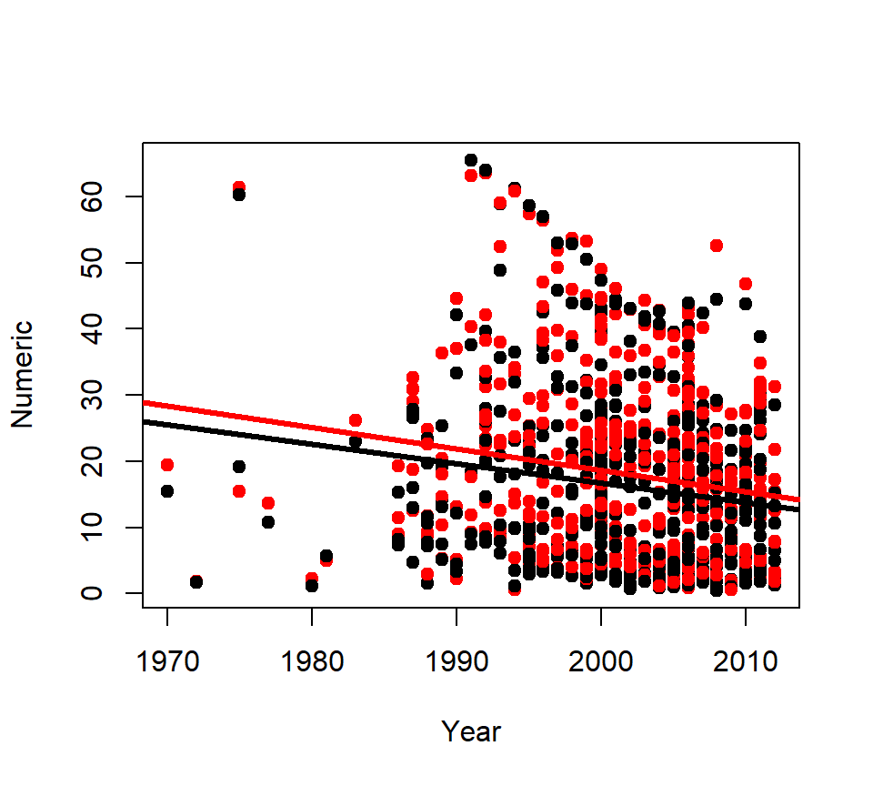

```r
# run linear model with Numeric vs Year for male and females
male.fit <- lm(Numeric ~ Year, data = hunger[hunger$Sex == "Male", ])
female.fit <- lm(Numeric ~ Year, data = hunger[hunger$Sex == "Female", ])
# plot % hungry vs the year
plot(Numeric ~ Year, data = hunger, pch = 19, col=(Sex=="Male")*1+1)
# plot regression lines for both
abline(male.fit, lwd = 3, col = "red")
abline(female.fit, lwd = 3, col = "black")
```

## 12.2 Model: % Hungry ~ Year + Sex (Binary Variable)

- this will include 1 model with 2 separate lines with the *same* slope
- model for % hungry ($H$) vs year ($Y$) and dummy variable for sex ($X$) is
  $$H_{i} = \beta_{0} + \beta_{1}X_i + \beta_{2} Y_{i} + \epsilon_{i}^*$$
  - $X_i$ = binary variable, $1$ if male, otherwise $0$
  - $\beta_{0}$ = % of females hungry at year 0
  - $\beta_{0} + \beta_{1}$ = % of males hungry at year 0
    - **Note**: the term $\beta_{1}X_i$ is effectively an **adjustment** for the intercept for males and DOES NOT alter the slope in anyway
    - $\beta_{1}$ = difference in means of males vs females
  - $\beta_{2}$ = decrease in % hungry (males and females) per year
    - this means that the slope is *constant* for both females and males
  - $\epsilon_{i}^*$ = standard error (or everything we didn’t measure)
    - we are still assuming Gaussian error term
- `abline(intercept, slope)` = adds a line to the existing plot based on the intercept and slope provided
  - `abline(lm)` = plots the linear regression line on the plot

```r
# run linear model with Numeric vs Year and Sex
both.fit <- lm(Numeric ~ Year+Sex, data = hunger)
# print fit
both.fit$coef
```

```
## (Intercept)        Year     SexMale
##  633.528289   -0.308397    1.902743
```

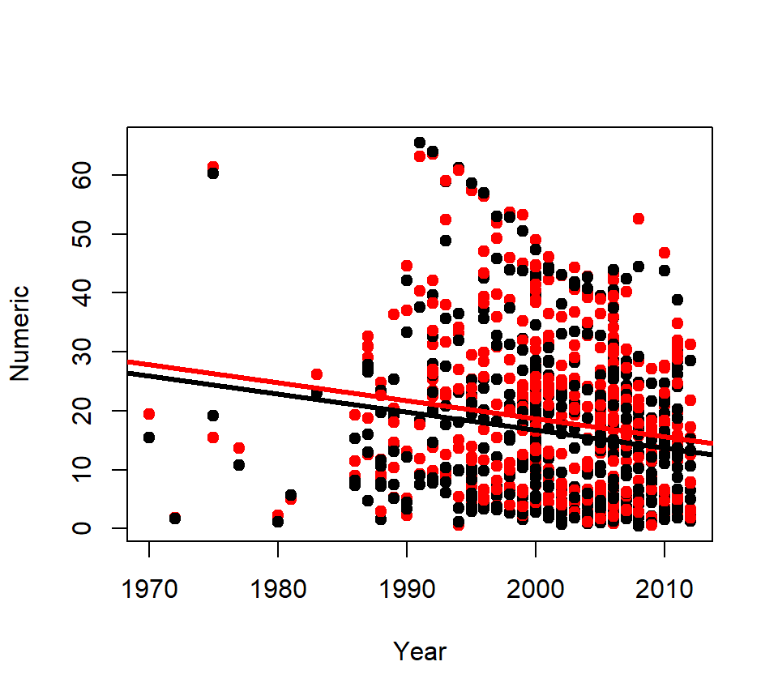

```r
# plot % hungry vs the year
plot(Numeric ~ Year, data = hunger, pch = 19, col=(Sex=="Male")*1+1)
# plot regression lines for both (same slope)
abline(both.fit$coef[1], both.fit$coef[2], lwd = 3, col = "black")
abline(both.fit$coef[1]+both.fit$coef[3], both.fit$coef[2], lwd = 3, col = "red")
```

## 12.3 Model: % Hungry ~ Year + Sex + Year * Sex (Binary Interaction)

- this will include 1 model with an interaction term with binary variable, which produces 2 lines with *different* slopes
- we can introduce an interaction term to the previous model to capture the different slopes between males and females
- model for % hungry ($H$) vs year ($Y$), sex ($X$), and interaction between year and sex ($Y \times X$) is
  $$H_{i} = \beta_{0} + \beta_{1}X_i + \beta_{2} Y_{i} + \beta_{3}X_i Y_{i} + \epsilon_{i}^+$$
  - $X_i$ = binary variable, $1$ if male, otherwise $0$
  - $\beta_{0}$ = % of females hungry at year 0
  - $\beta_{0} + \beta_{1}$ = % of males hungry at year 0
    - $\beta_{1}$ = change in *intercept* for males
  - $\beta_{2}$ = decrease in % hungry (females) per year
  - $\beta_{2} + \beta_{3}$ = decrease in % hungry (males) per year
    - $\beta_{3}$ = change in *slope* for males
  - $\epsilon_{i}^+$ = standard error (or everything we didn’t measure)
- expected value for males is $E[H_i]_M = (\beta_0 + \beta_1) + (\beta_2 + \beta_3) Y_i$
- expected value for females is $E[H_i]_F = \beta_0 + \beta_2 Y_i$
  - $\beta_1$ and $\beta_3$ are effectively adjusting the intercept and slope for males
- `lm(outcome ~ var1*var2)` = whenever an interaction is specified in `lm` function using the `*` operator, the individual terms are added automatically
  - `lm(outcome ~ var1+var2+var1*var2)` = builds the exact same model
  - `lm(outcome ~ var1:var2)` = builds linear model with *only* the interaction term (specified by `:` operator)

```r
# run linear model with Numeric vs Year and Sex and interaction term
interaction.fit <- lm(Numeric ~ Year*Sex, data = hunger)
# print fit
interaction.fit$coef
```

```
##  (Intercept)         Year      SexMale Year:SexMale
## 603.50579986  -0.29339638  61.94771998  -0.03000132
```

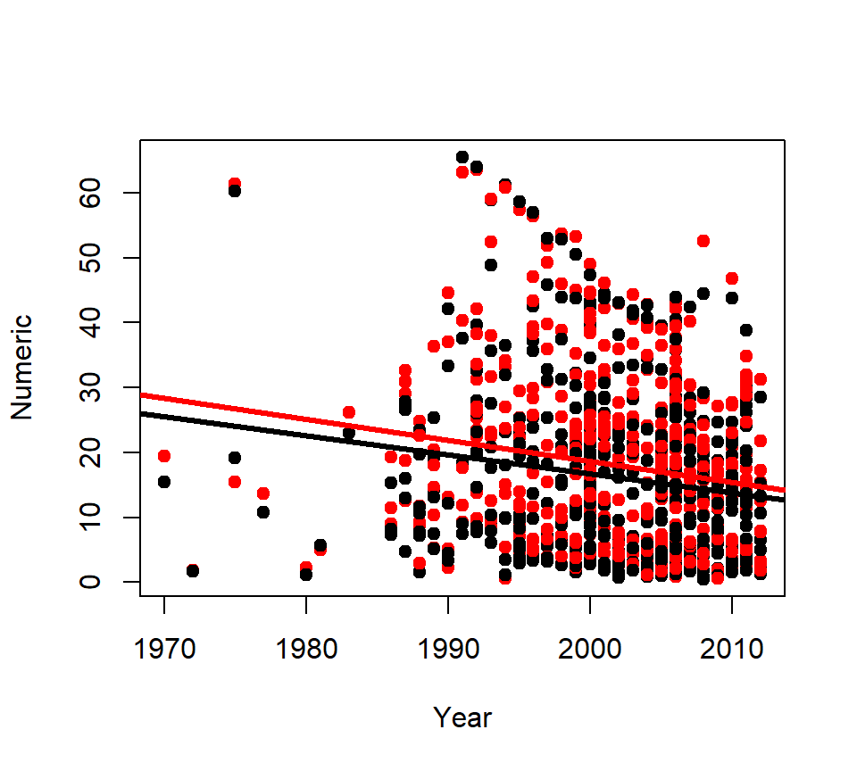

```r
# plot % hungry vs the year
plot(Numeric ~ Year, data = hunger, pch = 19, col=(Sex=="Male")*1+1)
# plot regression lines for both (different slope)
abline(interaction.fit$coef[1], interaction.fit$coef[2], lwd = 3, col = "black")
abline(interaction.fit$coef[1]+interaction.fit$coef[3],
    interaction.fit$coef[2]+interaction.fit$coef[4], lwd = 3, col = "red")
```

## 12.4 Example: % Hungry ~ Year + Income + Year * Income (Continuous Interaction)

- this will include 1 model with an interaction term with continuous variable, which produces a curve through the plot
- for **continuous interactions** (two continuous variables) with model
  $$Y{i} = \beta_{0} + \beta_{1} X_{1i} + \beta_{2} X_{2i} + \beta_{3} X_{1i} X_{2i} + \epsilon_{i}$$
  the expected value for a given set of values $x_1$ and $x_2$ is defined as
  $$E[Y_i|X_{1i}=x_1, X_{2i}=x_2] = \beta_{0} + \beta_{1} x_{1} + \beta_{2} x_{2} + \beta_{3} x_{1} x_{2}$$
- holding $X_2$ constant and varying $X_1$ by $1$, we have
  $$\begin{aligned}
  \frac{\partial Y_i}{\partial X_{1i}} & = E[Y_i|X_{1i}=x_1 + 1, X_{2i}=x_2] - E[Y_i|X_{1i}=x_1, X_{2i}=x_2] \\
  & = \beta_{0} + \beta_{1} (x_{1}+1) + \beta_{2} x_{2} + \beta_{3} (x_{1}+1) x_{2} - [\beta_{0} + \beta_{1} x_{1} + \beta_{2} x_{2} + \beta_{3} x_{1} x_{2}]\\
  & = \beta_{1} + \beta_{3} x_{2}\\
  \end{aligned}$$
  - **Note**: this means that slope for $X_{1i}$ is **not** constant and is **dependent** on $X_{2i}$
  - $\beta_1$ is the slope for $X_{1i}$ when $X_{2i}$ = 0
- by the same logic, if we vary $X_1$ by $1$ and find the change, and vary $X_2$ by $1$ and find the change, we get
  $$\begin{aligned}
  \frac{\partial}{\partial X_{2i}} \left(\frac{\partial Y_i}{\partial X_{1i}}\right) & = E[Y_i|X_{1i}=x_1 + 1, X_{2i}=x_2+1] - E[Y_i|X_{1i}=x_1, X_{2i}=x_2+1]\\
  & \qquad - \Big(E[Y_i|X_{1i}=x_1+1, X_{2i}=x_2] - E[Y_i|X_{1i}=x_1, X_{2i}=x_2]\Big)\\
  & = \beta_{0} + \beta_{1} (x_{1}+1) + \beta_{2} (x_{2}+1) + \beta_{3} (x_{1}+1) (x_{2}+1) - [\beta_{0} + \beta_{1} x_{1} + \beta_{2} (x_{2}+1) + \beta_{3} x_{1} (x_{2}+1)]\\
  & \qquad - \Big(\beta_{0} + \beta_{1} (x_{1}+1) + \beta_{2} x_{2} + \beta_{3} (x_{1}+1) x_{2} - [\beta_{0} + \beta_{1} x_{1} + \beta_{2} x_{2} + \beta_{3} x_{1} x_{2}]\Big)\\
  & = \beta_{3}\\
  \end{aligned}$$
  - this can be interpreted as $\beta_3$ = the **expected change in $Y$** per **unit change in $X_1$** per **unit change** of $X_2$
  - in other words, $\beta_3$ = the change in slope of $X_1$ and $Y$ per unit change of $X_2$
- coming back to the hunger data, model for % hungry ($H$) vs year ($Y$), income ($I$), and interaction between year and income ($Y \times I$) is
  $$H_{i} = \beta_{0} + \beta_{1}I_i + \beta_{2} Y_{i} + \beta_{3}I_i Y_{i} + \epsilon_{i}^+$$
  - $\beta_{0}$ = % hungry children (whose parents have no income) at year 0
  - $\beta_{1}$ = change in % hungry children for **each dollar in income** in year 0
  - $\beta_{2}$ = change in % hungry children (whose parents have no income) **per year**
  - $\beta_{3}$ = change in % hungry children **per year** and for **each dollar in income**
    - if income is $\$10,000$, then the change in % hungry children **per year** will be $\beta_2 + 10000 \times \beta_3$
  - $\epsilon_{i}^+$ = standard error (or everything we didn’t measure)
- **Note**: much care needs to be taken when interpreting these coefficients

```r
# generate some income data
hunger$Income <- 1:nrow(hunger)*10 + 500*runif(nrow(hunger), 0, 10) +
    runif(nrow(hunger), 0, 500)^1.5
# run linear model with Numeric vs Year and Income and interaction term
lm(Numeric ~ Year*Income, data = hunger)$coef
```

```
##   (Intercept)          Year        Income   Year:Income
##  9.070867e+02 -4.444612e-01 -2.380647e-02  1.188212e-05
```

# 13 Multivariable Simulation

- **Intro**: Adjustment, is the idea of putting regressors into a linear model to investigate the role of a third variable on the relationship between another two. Since it is often the case that a third variable can distort, or confound if you will, the relationship between two others.  
  As an example, consider looking at lung cancer rates and breath mint usage. For the sake of completeness, imagine if you were looking at forced expiratory volume (a measure of lung function) and breath mint usage. If you found a statistically significant regression relationship, it wouldn’t be wise to rush off to the newspapers with the headline “Breath mint usage causes shortness of breath!”, for a variety of reasons. First off, even if the association is sound, you don’t know that it’s causal. But, more importantly in this case, the likely culprit is smoking habits. Smoking rates are likely related to both breath mint usage rates and lung function. How would you defend your finding against the accusation that it’s just variability in smoking habits?  
  If your finding held up among non-smokers and smokers analyzed separately, then you might have something. In other words, people wouldn’t even begin to believe this finding unless it held up while holding smoking status constant. That is the idea of adding a regression variable into a model as adjustment. The coefficient of interest is interpreted as the effect of the predictor on the response, holding the adjustment variable constant.  
  In this lecture, we’ll use simulation to investigate how adding a regressor into a model addresses the idea of adjustment.
- we will generate a series of simulated data so that we know the true relationships, and then run linear regressions to interpret and compare the results to truth
- **treatment effect** = effect of adding the treatment variable $t$ to the regression model (i.e. how adding $t$ changes the regression lines)
  - effectively measures how much the regression lines for the two groups separate with regression `lm(y ~ x + t)`
- **adjustment effect** = adjusting the regression for effects of $x$ such that we just look at how $t$ is *marginally related* to $Y$
  - ignore all variation of $x$ and simply look at the group means of $t = 1$ vs $t = 0$

## 13.1 Simulation 1 - Treatment = Adjustment Effect

- the following code simulates the linear model,
  $$Y_i = \beta_0 + \beta_1 x_i + \beta_2 t_i + \epsilon_i$$
  where $t = \{0, 1\} \rightarrow$ binary variable

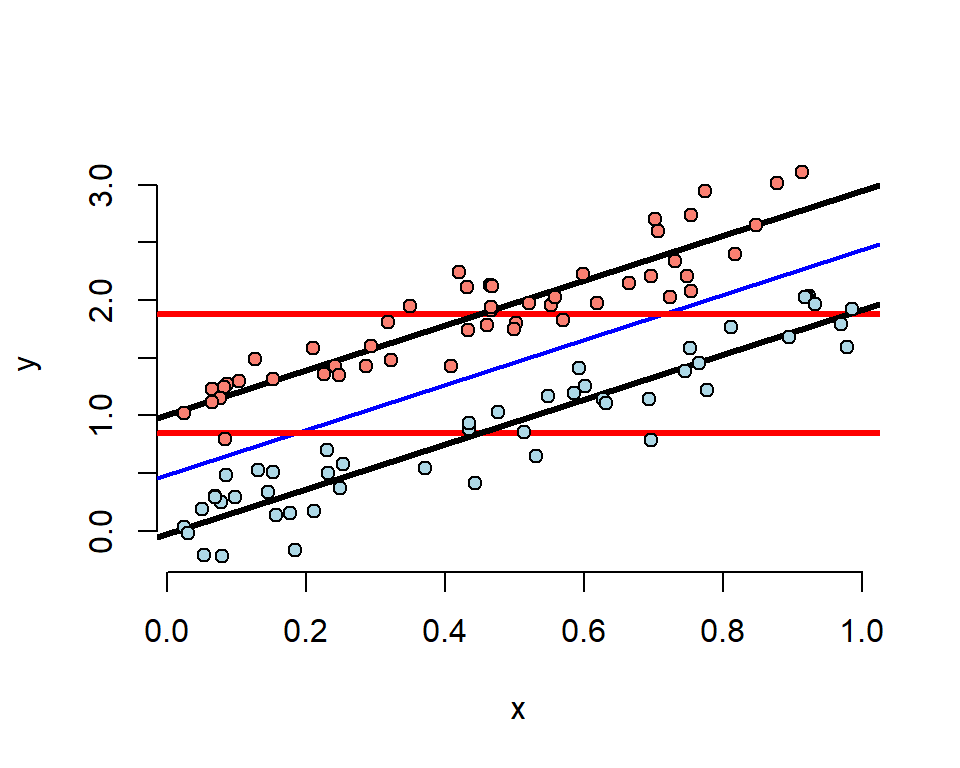

```r
# simulate data
n <- 100; t <- rep(c(0, 1), c(n/2, n/2)); x <- c(runif(n/2), runif(n/2));
# define parameters/coefficients
beta0 <- 0; beta1 <- 2; beta2 <- 1; sigma <- .2
# generate outcome using linear model
y <- beta0 + x * beta1 + t * beta2 + rnorm(n, sd = sigma)
# set up axes
plot(x, y, type = "n", frame = FALSE)
# plot linear fit of y vs x
abline(lm(y ~ x), lwd = 2, col = "blue")
# plot means of the two groups (t = 0 vs t = 1)
abline(h = mean(y[1 : (n/2)]), lwd = 3, col = "red")
abline(h = mean(y[(n/2 + 1) : n]), lwd = 3, col = "red")
# plot linear fit of y vs x and t
fit <- lm(y ~ x + t)
# plot the two lines corresponding to (t = 0 vs t = 1)
abline(coef(fit)[1], coef(fit)[2], lwd = 3)
abline(coef(fit)[1] + coef(fit)[3], coef(fit)[2], lwd = 3)
# add in the actual data points
points(x[1 : (n/2)], y[1 : (n/2)], pch = 21, col = "black", bg = "lightblue", cex = 1)
points(x[(n/2 + 1) : n], y[(n/2 + 1) : n], pch = 21, col = "black", bg = "salmon", cex = 1)
```

```r
# print treatment and adjustment effects
rbind("Treatment Effect" = lm(y~t+x)$coef[2], "Adjustment Effect" = lm(y~t)$coef[2])
```

```
##                          t
## Treatment Effect  1.032264
## Adjustment Effect 1.038502
```

- in the above graph, the elements are as follows:
  - $red$ lines = means for two groups ($t = 0$ vs $t = 1$) $\rightarrow$ two lines representing `lm(y ~ t)`
  - $black$ lines = regression lines for two groups ($t = 0$ vs $t = 1$) $\rightarrow$ two lines representing `lm(y ~ t + x)`
  - $blue$ line = overall regression of $y$ vs $x$ $\rightarrow$ line representing `lm(y ~ x)`
- from the graph, we can see that
  - $x$ variable is *unrelated* to group status $t$
    - distribution of each group (salmon vs light blue) of $Y$ vs $X$ is effectively the same
  - $x$ variable is *related* to $Y$, but the intercept **depends** on group status $t$
  - group variable $t$ is *related* to $Y$
    - relationship between $t$ and $Y$ disregarding $x \approx$ the same as holding $x$ constant
    - difference in group means $\approx$ difference in regression lines
    - *treatment effect* (difference in regression lines) $\approx$ *adjustment effect* (difference in group means)

## 13.2 Simulation 2 - No Treatment Effect

- the following code simulates the linear model,
  $$Y_i = \beta_0 + \beta_1 x_i + \beta_2 t_i + \epsilon_i$$
  where $t = \{0, 1\} \rightarrow$ binary variable
- in this case, $\beta_2$ is set to $0$

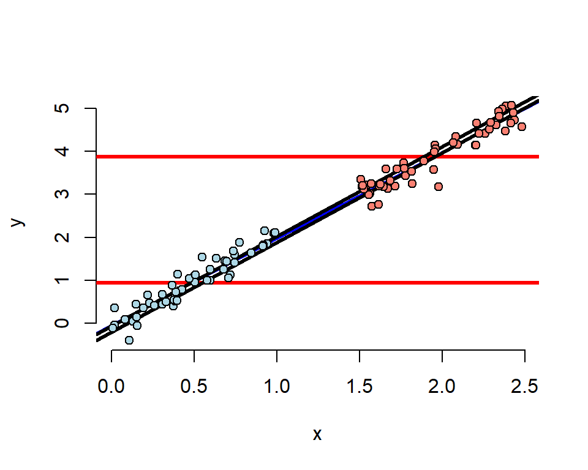

```r
# simulate data
n <- 100; t <- rep(c(0, 1), c(n/2, n/2)); x <- c(runif(n/2), 1.5 + runif(n/2));
# define parameters/coefficients
beta0 <- 0; beta1 <- 2; beta2 <- 0; sigma <- .2
# generate outcome using linear model
y <- beta0 + x * beta1 + t * beta2 + rnorm(n, sd = sigma)
# set up axes
plot(x, y, type = "n", frame = FALSE)
# plot linear fit of y vs x
abline(lm(y ~ x), lwd = 2, col = "blue")
# plot means of the two groups (t = 0 vs t = 1)
abline(h = mean(y[1 : (n/2)]), lwd = 3, col = "red")
abline(h = mean(y[(n/2 + 1) : n]), lwd = 3, col = "red")
# plot linear fit of y vs x and t
fit <- lm(y ~ x + t)
# plot the two lines corresponding to (t = 0 vs t = 1)
abline(coef(fit)[1], coef(fit)[2], lwd = 3)
abline(coef(fit)[1] + coef(fit)[3], coef(fit)[2], lwd = 3)
# add in the actual data points
points(x[1 : (n/2)], y[1 : (n/2)], pch = 21, col = "black", bg = "lightblue", cex = 1)
points(x[(n/2 + 1) : n], y[(n/2 + 1) : n], pch = 21, col = "black", bg = "salmon", cex = 1)
```

```r
# print treatment and adjustment effects
rbind("Treatment Effect" = lm(y~t+x)$coef[2], "Adjustment Effect" = lm(y~t)$coef[2])
```

```
##                           t
## Treatment Effect  -0.134853
## Adjustment Effect  2.936620
```

- in the above graph, the elements are as follows:
  - $red$ lines = means for two groups ($t = 0$ vs $t = 1$) $\rightarrow$ two lines representing `lm(y ~ t)`
  - $black$ lines = regression lines for two groups ($t = 0$ vs $t = 1$) $\rightarrow$ two lines representing `lm(y ~ t + x)`
    - in this case, both lines correspond to `lm(y ~ x)` since coefficient of $t$ or $\beta_2 = 0$
  - $blue$ line = overall regression of $y$ vs $x$ $\rightarrow$ line representing `lm(y ~ x)`
    - this is overwritten by the $black$ lines
- from the graph, we can see that
  - $x$ variable is *highly related* to group status $t$
    - clear shift in $x$ with salmon vs light blue groups
  - $x$ variable is *related* to $Y$, but the intercept **does not depend** on group status $t$
    - intercepts for both lines are the same
  - $x$ variable shows *similar relationships* to $Y$ for both groups ($t = 0$ vs $t = 1$, or salmon vs lightblue)
    - the $x$ values of the two groups of points both seem to be linearly correlated with $Y$
  - group variable $t$ is *marginally related* to $Y$ when disregarding X
    - $x$ values capture most of the variation
    - *adjustment effect* (difference in group means) is very large
  - group variable $t$ is *unrelated or has very little* effect on $Y$
    - *treatment effect* is very small or non-existent
    - **Note**: the groups ($t = 0$ vs $t = 1$) are **incomparable** since there is no data to inform the relationship between $t$ and $Y$
    - the groups (salmon vs lightblue) don’t have any overlaps so we have no idea how they behave
    - this conclusion is based on the constructed alone

## 13.3 Simulation 3 - Treatment Reverses Adjustment Effect

- the following code simulates the linear model,
  $$Y_i = \beta_0 + \beta_1 x_i + \beta_2 t_i + \epsilon_i$$
  where $t = \{0, 1\} \rightarrow$ binary variable
- in this case, $\beta_0$ is set to $0$ $\rightarrow$ no intercept

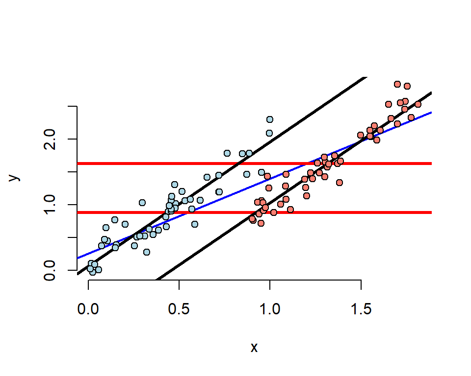

```r
# simulate data
n <- 100; t <- rep(c(0, 1), c(n/2, n/2)); x <- c(runif(n/2), .9 + runif(n/2));
# define parameters/coefficients
beta0 <- 0; beta1 <- 2; beta2 <- -1; sigma <- .2
# generate outcome using linear model
y <- beta0 + x * beta1 + t * beta2 + rnorm(n, sd = sigma)
# set up axes
plot(x, y, type = "n", frame = FALSE)
# plot linear fit of y vs x
abline(lm(y ~ x), lwd = 2, col = "blue")
# plot means of the two groups (t = 0 vs t = 1)
abline(h = mean(y[1 : (n/2)]), lwd = 3, col = "red")
abline(h = mean(y[(n/2 + 1) : n]), lwd = 3, col = "red")
# plot linear fit of y vs x and t
fit <- lm(y ~ x + t)
# plot the two lines corresponding to (t = 0 vs t = 1)
abline(coef(fit)[1], coef(fit)[2], lwd = 3)
abline(coef(fit)[1] + coef(fit)[3], coef(fit)[2], lwd = 3)
# add in the actual data points
points(x[1 : (n/2)], y[1 : (n/2)], pch = 21, col = "black", bg = "lightblue", cex = 1)
points(x[(n/2 + 1) : n], y[(n/2 + 1) : n], pch = 21, col = "black", bg = "salmon", cex = 1)
```

```r
# print treatment and adjustment effects
rbind("Treatment Effect" = lm(y~t+x)$coef[2], "Adjustment Effect" = lm(y~t)$coef[2])
```

```
##                            t
## Treatment Effect  -0.9304306
## Adjustment Effect  0.7482072
```

- in the above graph, the elements are as follows:
  - $red$ lines = means for two groups ($t = 0$ vs $t = 1$) $\rightarrow$ two lines representing `lm(y ~ t)`
  - $black$ lines = regression lines for two groups ($t = 0$ vs $t = 1$) $\rightarrow$ two lines representing `lm(y ~ t + x)`
  - $blue$ line = overall regression of $y$ vs $x$ $\rightarrow$ line representing `lm(y ~ x)`
- from the graph, we can see that
  - disregarding/adjusting for $x$, the mean for salmon group is *higher* than the mean of the blue group (*adjustment effect* is positive)
  - when adding $t$ into the linear model, the treatment actually reverses the orders of the group $\rightarrow$ the intercept of the salmon group is *lower* than the intercept of the blue group (*treatment effect* is negative)
    - adjusted estimate is significant and the exact opposite of our unadjusted estimate
  - group variable $t$ is *related* to $x$
  - some points overlap so it is possible to compare the subsets two groups holding $x$ fixed

## 13.4 Simulation 4 - No Adjustment Effect

- the following code simulates the linear model,
  $$Y_i = \beta_0 + \beta_1 x_i + \beta_2 t_i + \epsilon_i$$
  where $t = \{0, 1\} \rightarrow$ binary variable
- in this case, $\beta_0$ is set to $0$ $\rightarrow$ no intercept
  - No Adjustment or Marginal Effect

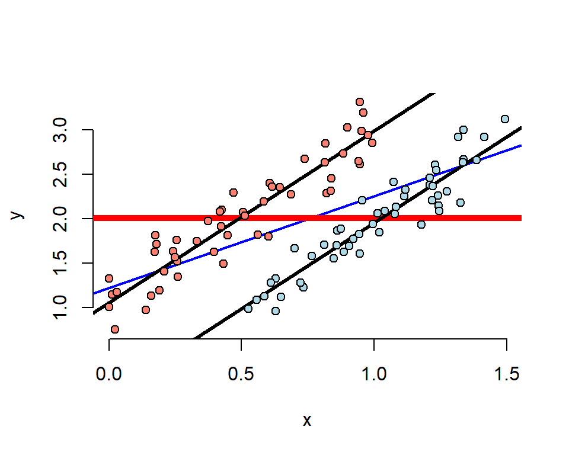

```r
# simulate data
n <- 100; t <- rep(c(0, 1), c(n/2, n/2)); x <- c(.5 + runif(n/2), runif(n/2));
# define parameters/coefficients
beta0 <- 0; beta1 <- 2; beta2 <- 1; sigma <- .2
# generate outcome using linear model
y <- beta0 + x * beta1 + t * beta2 + rnorm(n, sd = sigma)
# set up axes
plot(x, y, type = "n", frame = FALSE)
# plot linear fit of y vs x
abline(lm(y ~ x), lwd = 2, col = "blue")
# plot means of the two groups (t = 0 vs t = 1)
abline(h = mean(y[1 : (n/2)]), lwd = 3, col = "red")
abline(h = mean(y[(n/2 + 1) : n]), lwd = 3, col = "red")
# plot linear fit of y vs x and t
fit <- lm(y ~ x + t)
# plot the two lines corresponding to (t = 0 vs t = 1)
abline(coef(fit)[1], coef(fit)[2], lwd = 3)
abline(coef(fit)[1] + coef(fit)[3], coef(fit)[2], lwd = 3)
# add in the actual data points
points(x[1 : (n/2)], y[1 : (n/2)], pch = 21, col = "black", bg = "lightblue", cex = 1)
points(x[(n/2 + 1) : n], y[(n/2 + 1) : n], pch = 21, col = "black", bg = "salmon", cex = 1)
```

```r
# print treatment and adjustment effects
rbind("Treatment Effect" = lm(y~t+x)$coef[2], "Adjustment Effect" = lm(y~t)$coef[2])
```

```
##                            t
## Treatment Effect  1.03068513
## Adjustment Effect 0.02677364
```

## 13.5 Simulation 5 - Binary Interaction

- the following code simulates the linear model,
  $$Y_i = \beta_0 + \beta_1 x_i + \beta_2 t_i + \beta_3 x_i t_i + \epsilon_i$$
  where $t = \{0, 1\} \rightarrow$ binary variable
- in this case, $\beta_0$ and $\beta_2$ are set to $0$

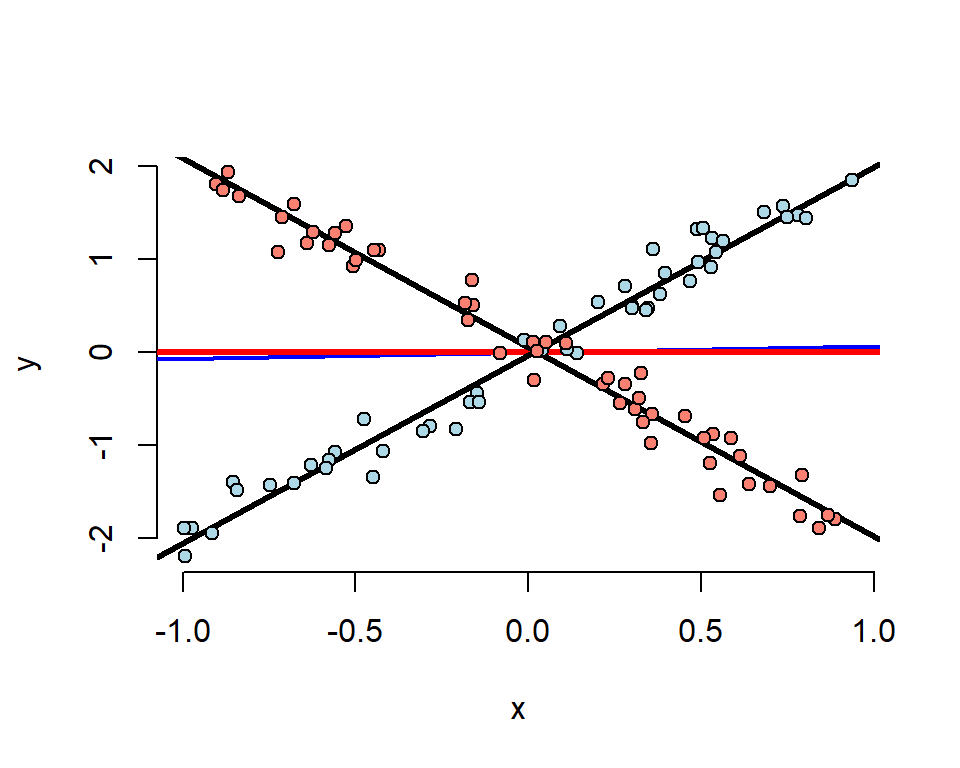

```r
# simulate data
n <- 100; t <- rep(c(0, 1), c(n/2, n/2)); x <- c(runif(n/2, -1, 1), runif(n/2, -1, 1));
# define parameters/coefficients
beta0 <- 0; beta1 <- 2; beta2 <- 0; beta3 <- -4; sigma <- .2
# generate outcome using linear model
y <- beta0 + x * beta1 + t * beta2 + t * x * beta3 + rnorm(n, sd = sigma)
# set up axes
plot(x, y, type = "n", frame = FALSE)
# plot linear fit of y vs x
abline(lm(y ~ x), lwd = 2, col = "blue")
# plot means of the two groups (t = 0 vs t = 1)
abline(h = mean(y[1 : (n/2)]), lwd = 3, col = "red")
abline(h = mean(y[(n/2 + 1) : n]), lwd = 3, col = "red")
# plot linear fit of y vs x and t and interaction term
fit <- lm(y ~ x + t + I(x * t))
# plot the two lines corresponding to (t = 0 vs t = 1)
abline(coef(fit)[1], coef(fit)[2], lwd = 3)
abline(coef(fit)[1] + coef(fit)[3], coef(fit)[2] + coef(fit)[4], lwd = 3)
# add in the actual data points
points(x[1 : (n/2)], y[1 : (n/2)], pch = 21, col = "black", bg = "lightblue", cex = 1)
points(x[(n/2 + 1) : n], y[(n/2 + 1) : n], pch = 21, col = "black", bg = "salmon", cex = 1)
```

- in the above graph, the elements are as follows:
  - $red$ lines = means for two groups ($t = 0$ vs $t = 1$) $\rightarrow$ two lines representing `lm(y ~ t)`
  - $black$ lines = regression lines for two groups ($t = 0$ vs $t = 1$) $\rightarrow$ two lines representing `lm(y ~ t + x + t*x)`
  - $blue$ line = overall regression of $y$ vs $x$ $\rightarrow$ line representing `lm(y ~ x)`
    - this is completely meaningless in this case
- from the graph, we can see that
  - *treatment effect* does **not** apply since it varies with $x$
    - impact of treatment/group variable **reverses itself** depending on $x$
    - compare $X$ ard 0.0 & $X$ ard 1.0 $\rightarrow$ no difference between blue and red & blue higher than red
  - *adjustment effect* is effectively zero as the means of the two groups are very similar
  - both intercept and slope of the two lines depend on the group variable $t$
  - group variable and $x$ are *unrelated*
  - lots of information for comparing group effects holding $x$ fixed